# Markdown - Measuring the effects of AI introduction on MNEs’ innovative performance

This html file is divided into 3 main parts. In the **first part**, the technological distance of 4-digit IPC codes to AI is measured, as well as the estimated distance of NACE sectors to AI. In the **second part**, the DiD estimations are calculated for the variables considered in the paper. Finally, the **third part** provides the descriptive statistics shown in the Appendices of the paper, as well as correlations not included in the paper.

# 1. Measuring technological distances: from 4-digit IPC codes to AI technologies, and from NACE sectors to AI.

This section details the methodology used to calculate the technological distance of different industry sectors and patent codes from AI. We begin by measuring the distance of 4-digit International Patent Classification (IPC) codes to a defined set of AI patents. Following this, we treat AI as its own technological “sector” to measure the distance of NACE sectors to this new “AI sector”

## 1.1. Technological distance of 4-digit IPC codes to AI

In this subsection, we start by loading and preparing the necessary patent and company data. This data, which is proprietary and not publicly available, links patents to multinational enterprises (MNEs) and their respective NACE sectors.

Our patent file, after being loaded and pre-processed, contains a number of variables, including a unique publication number (PubNo), the company ID (Company), and the corresponding 4-digit International Patent Classification (IPC) code for the technology (Subclass). This is a sample of the data:

```r
kable(head(all_patents[, c("PubNo", "AIpatent", "Subclass", "Company", "Subsidiaries", "Nace_4d","Priority_year")], 5),
      caption = "Sample of the Patent Data",
      col.names = c("Publication No.", "Is AI Patent", "IPC Subclass", "Company ID (GUO)", "Linked Subsidiary","Nace code from the Company","Year"))
```

Sample of the Patent Data

| Publication No. | Is AI Patent | IPC Subclass | Company ID (GUO) | Linked Subsidiary | Nace code from the Company | Year |
| --- | --- | --- | --- | --- | --- | --- |
| US20110020687A1 | NA | H01M | AE0000037109 | US170250798L | 2620 | 2009 |
| WO2010138209A1 | NA | H01M | AE0000037109 | US170250798L | 2620 | 2009 |
| US20110020687A1 | NA | H01R | AE0000037109 | US170250798L | 2620 | 2009 |
| IN4275CHE2011A | NA | G06Q | AE0000037976 | IN0007629103 | 4762 | 2011 |
| KR1020110026170A | NA | B29C | AE0000040745 | AE0000040745 | 7739 | 2009 |

Next, we introduce AI as a distinct technology by creating a new category named “Artificial_Intelligence”. We then build a co-occurrence matrix to measure how often different patent codes appear together. This matrix is the foundation for calculating the technological distance between IPC codes.

```r
# Define a function for fractional counting of IPC codes
group_by_applnID <- function (data){
  data %>%
    group_by(PubNo) %>%
    mutate(field_weight = 1 / n()) %>%
    ungroup()
}

# Define a function to count the relative participation of each IPC code per NACE sector
group_by_NACE_and_Subclass <- function (data){
  data %>%
    group_by(Nace_4d, Subclass) %>%
    summarise(n_tech_reg = sum(field_weight)) %>%
    ungroup() %>%
    drop_na()
}

# Define a function to create a sparse matrix from a data frame
create_sparse_matrix <- function(i.input, j.input){
  require(Matrix)
  mat <- spMatrix(
    nrow = i.input %>% n_distinct(),
    ncol = j.input %>% n_distinct(),
    i = i.input %>% factor() %>% as.numeric(),
    j = j.input %>% factor() %>% as.numeric(),
    x = rep(1, i.input %>% length())
  )

  row.names(mat) <- i.input %>% factor() %>% levels()
  colnames(mat) <- j.input %>% factor() %>% levels()
  return(mat)
}

# Introduce a new "Artificial_Intelligence" subclass for AI patents
AI_Patents <- all_patents[all_patents$AIpatent == "Yes", ]
AI_Patents_with_code <- distinct_at(AI_Patents, vars(PubNo, Company), .keep_all = T)
AI_Patents_with_code$Subclass <- "Artificial_Intelligence"
AI_Patents <- rbind(AI_Patents, AI_Patents_with_code)
all_patents <- rbind(all_patents, AI_Patents)
rm(AI_Patents_with_code, AI_Patents)

# Create a square co-occurrence matrix of all IPC codes
mat_tech <- create_sparse_matrix(i = all_patents %>% pull(PubNo),
                                 j = all_patents %>% pull(Subclass))

mat_tech %<>%
  crossprod() %>%
  as.matrix()
```

This co-occurrence matrix shows how often two IPC codes appear in the same patent. This is a sample of what the matrix looks like:

```r
kable(as.data.frame(mat_tech[1:10, 1:5]),
      caption = "Sample of the Co-occurrence Matrix")
```

Sample of the Co-occurrence Matrix

|  | A01B | A01C | A01D | A01F | A01G |
| --- | --- | --- | --- | --- | --- |
| A01B | 6526 | 1161 | 645 | 50 | 252 |
| A01C | 1161 | 6710 | 71 | 16 | 580 |
| A01D | 645 | 71 | 10082 | 1115 | 236 |
| A01F | 50 | 16 | 1115 | 3362 | 8 |
| A01G | 252 | 580 | 236 | 8 | 12912 |
| A01H | 8 | 82 | 21 | 0 | 387 |
| A01J | 0 | 0 | 0 | 0 | 1 |
| A01K | 5 | 8 | 10 | 24 | 290 |
| A01L | 0 | 0 | 0 | 0 | 0 |
| A01M | 149 | 386 | 40 | 3 | 316 |

Finally, we calculate the relatedness of every technology to AI using a cosine similarity metric. This metric gives us a measure of technological distance, where a higher value indicates a closer relationship.

```r
mat_tech %<>%
  relatedness(method = "cosine")
```

A sample of the resulting relatedness matrix:

```r
kable(as.data.frame(mat_tech[1:10, 1:5]),
      caption = "Sample of the Relatedness Matrix")
```

Sample of the Relatedness Matrix

|  | A01B | A01C | A01D | A01F | A01G |
| --- | --- | --- | --- | --- | --- |
| A01B | 0.0000000 | 0.1886887 | 0.0971825 | 0.0136373 | 0.0285017 |
| A01C | 0.1886887 | 0.0000000 | 0.0115356 | 0.0047058 | 0.0707380 |
| A01D | 0.0971825 | 0.0115356 | 0.0000000 | 0.3040212 | 0.0266840 |
| A01F | 0.0136373 | 0.0047058 | 0.3040212 | 0.0000000 | 0.0016374 |
| A01G | 0.0285017 | 0.0707380 | 0.0266840 | 0.0016374 | 0.0000000 |
| A01H | 0.0008472 | 0.0093644 | 0.0022233 | 0.0000000 | 0.0307563 |
| A01J | 0.0000000 | 0.0000000 | 0.0000000 | 0.0000000 | 0.0003706 |
| A01K | 0.0006561 | 0.0011321 | 0.0013119 | 0.0056995 | 0.0285585 |
| A01L | 0.0000000 | 0.0000000 | 0.0000000 | 0.0000000 | 0.0000000 |
| A01M | 0.0218931 | 0.0611593 | 0.0058756 | 0.0007977 | 0.0348433 |

This matrix is a critical output of our analysis, saved as “Matrix_relatedness_technologies_to_AI.csv”. We can use it to identify which 4-digit IPC codes are most closely related to AI. For example, the ten most related codes are:

```r
mat_subset_df <- as.data.frame(mat_tech) %>%
  rownames_to_column(var = "4-digitsIPC")
mat_subset_df <- as.data.frame(mat_subset_df[, c("4-digitsIPC", "Artificial_Intelligence")])
top_10_codes <- mat_subset_df %>% arrange(desc(Artificial_Intelligence)) %>% head(10)
kable(top_10_codes, caption = "Top 10 IPC Codes Most Related to AI")
```

Top 10 IPC Codes Most Related to AI

| 4-digitsIPC | Artificial_Intelligence |
| --- | --- |
| G06N | 0.1638343 |
| G06F | 0.1131839 |
| G06K | 0.1041677 |
| G06Q | 0.0975695 |
| G06T | 0.0667038 |
| G10L | 0.0586685 |
| H04L | 0.0436660 |
| G05B | 0.0417651 |
| G16H | 0.0399282 |
| A61B | 0.0324227 |

## 1.2. Technological distance of NACE sectors to AI

Now, we shift our focus to measure the technological distance of NACE sectors to AI. We achieve this by first calculating the patent specializations of each NACE sector and then measuring the overlap between these specializations and a pre-defined set of top AI-related technologies.

```r
rm(mat_tech)
# Reload original patents without the "Artificial_Intelligence" subclass
all_patents <- fread("Input_code/Big_files_ignore/All_patents.csv")
CompaniesData <- read_excel("Input_code/Big_files_ignore/DataCompanies1.xlsx", sheet = "Results", na = "n.a.")
# Read and combine the company data again for a clean start
CompaniesData <- rbind(CompaniesData, read_excel("Input_code/Big_files_ignore/DataCompanies2.xlsx", sheet = "Results", na = "n.a."))
CompaniesData <- rbind(CompaniesData, read_excel("Input_code/Big_files_ignore/DataCompanies3.xlsx", sheet = "Results", na = "n.a."))
CompaniesData <- rbind(CompaniesData, read_excel("Input_code/Big_files_ignore/DataCompanies4.xlsx", sheet = "Results", na = "n.a."))
CompaniesData <- rbind(CompaniesData, read_excel("Input_code/Big_files_ignore/DataCompanies5.xlsx", sheet = "Results", na = "n.a."))
CompaniesData <- rbind(CompaniesData, read_excel("Input_code/Big_files_ignore/DataCompanies6.xlsx", sheet = "Results", na = "n.a."))
CompaniesData <- CompaniesData[,c(2,3,6)]
names(CompaniesData) <- c("Company_name", "Company", "Nace_4d")

all_patents <- left_join(all_patents, CompaniesData, by = "Company")
all_patents <- all_patents[is.na(all_patents$Nace_4d) == F, ] # Drop companies without Nace codes
all_patents <- all_patents[, -7] # Exclude company name

# Count total patents per sector and total AI patents for descriptive purposes
all_patents %<>% group_by(Nace_4d) %>%
  mutate(TotalPatents = length(unique(PubNo))) %>%
  mutate(TotalAIPatents = length(na.omit(unique(PubNo[AIpatent == "Yes"])))) %>%
  mutate(ShareAI = TotalAIPatents / TotalPatents) %>%
  ungroup()

# Apply functions to get relative participation of IPC codes per NACE sector
reg_tech <- group_by_applnID(all_patents) # Fractional counting of IPC codes
reg_tech <- group_by_NACE_and_Subclass(reg_tech) # Sum of relative participation
```

Here’s a snapshot of the relative participation of each IPC code within each NACE sector:

```r
kable(head(reg_tech, 5), caption = "Relative Patent Participation per NACE Sector")
```

Relative Patent Participation per NACE Sector

| Nace_4d | Subclass | n_tech_reg |
| --- | --- | --- |
| 0111 | A01B | 0.5000000 |
| 0111 | A01C | 3.0000000 |
| 0111 | A01D | 2.0833333 |
| 0111 | A01F | 0.3333333 |
| 0111 | A01G | 25.4166667 |

Next, we convert this data into a matrix to calculate the Revealed Comparative Advantage (RCA), which identifies a sector’s patent specializations.

```r
# Reshape data into a matrix format
mat_reg_tech <- reg_tech %>%
  arrange(Subclass) %>%
  pivot_wider(names_from = Subclass, values_from = n_tech_reg, values_fill = list(n_tech_reg = 0))

# Set Nace codes as row names and convert to a matrix
mat_reg_tech %<>%
  remove_rownames() %>%
  column_to_rownames(var = "Nace_4d") %>%
  as.matrix() %>%
  round()

# Calculate binary specializations (RCA > 1)
rel_sectors_codes <- mat_reg_tech %>%
  location_quotient(binary = T) %>%
  as.data.frame() %>%
  rownames_to_column("mat_reg_tech") %>%
  as_tibble() %>%
  gather(key = "Subclass", value = "RCA", -mat_reg_tech) %>%
  arrange(mat_reg_tech, Subclass)
```

A sample of the binary specialization data:

```r
kable(head(rel_sectors_codes, 5), caption = "Sample of Patent Specializations (RCA)")
```

Sample of Patent Specializations (RCA)

| mat_reg_tech | Subclass | RCA |
| --- | --- | --- |
| 0111 | A01B | 0 |
| 0111 | A01C | 1 |
| 0111 | A01D | 1 |
| 0111 | A01F | 0 |
| 0111 | A01G | 1 |

Now, we read the relatedness matrix created in the previous section and select the top 9 most related AI codes to define our AI cluster.

```r
# Load the relatedness matrix and select top AI codes
mat_tech_rel <- read.csv2("Output_code/Data/Matrix_relatedness_technologies_to_AI.csv")
mat_tech_rel <- mat_tech_rel[, c("X", "Artificial_Intelligence")]
AI_codes_top9 <- mat_tech_rel[mat_tech_rel$Artificial_Intelligence > .038, 1]

# The top 9 codes are:
# G06F: Electric Digital Data Processing
# G06K: Recognition of Data
# G06N: Computer Systems Based on Specific Computational Models (Core AI)
# G06Q: Data Processing for Administrative Purposes
# G06T: Image Data Processing
# G10L: Speech Analysis or Synthesis
# H04L: Transmission of Digital Information
# G05B: Control or Regulating Systems
# G16H: Health Informatics

# Count specializations that coincide with these top 9 AI codes
count_specializations <- function(data, code_list, column_name) {
  data %>% mutate(
    !!column_name := case_when(
      Subclass %in% code_list & RCA == 1 ~ 1,
      TRUE ~ 0
    )
  ) %>%
    group_by(mat_reg_tech) %>%
    summarise(!!column_name := sum(!!as.symbol(column_name), na.rm = TRUE), .groups = "drop")
}

rel_sectors_codes <- rel_sectors_codes %>%
  left_join(count_specializations(rel_sectors_codes, AI_codes_top9, "AI_specializations_top9"), by = "mat_reg_tech")

names(rel_sectors_codes)[names(rel_sectors_codes) == 'mat_reg_tech'] <- 'Nace_4d'

# Calculate the share of specializations for each NACE sector
rel_sectors_codes %<>% group_by(Nace_4d) %>%
  mutate(number_spec = length(unique(Subclass[RCA == 1]))) %>%
  mutate(Share_top9 = AI_specializations_top9 / number_spec) %>%
  ungroup()

Unique_sectors <- distinct_at(rel_sectors_codes, vars(Nace_4d), .keep_all = T)
Unique_sectors <- subset(Unique_sectors, select = -c(Subclass))
Unique_sectors <- Unique_sectors %>%
  mutate(across(everything(), ~ ifelse(is.nan(.), 0, .)))
```

Finally, we categorize NACE sectors into quartiles based on their Share_top9 to create a Quartile variable. This categorization allows for a more granular analysis in later sections.

```r
# Define a function to create quartile variables
create_quartile_variable <- function(data, share_column, quartile_column_name) {
  share_column_sym <- sym(share_column)
  data %>%
    mutate(
      !!quartile_column_name := case_when(
        between(!!share_column_sym,
                quantile(!!share_column_sym, 0, na.rm = TRUE),
                quantile(!!share_column_sym, 0.25, na.rm = TRUE)) ~ "Bottom",
        between(!!share_column_sym,
                quantile(!!share_column_sym, 0.25, na.rm = TRUE),
                quantile(!!share_column_sym, 0.75, na.rm = TRUE)) ~ "IQR",
        between(!!share_column_sym,
                quantile(!!share_column_sym, 0.75, na.rm = TRUE),
                quantile(!!share_column_sym, 1, na.rm = TRUE)) ~ "Top",
        TRUE ~ NA_character_
      )
    )
}

# Apply the quartile function to our data
Unique_sectors <- Unique_sectors %>%
  create_quartile_variable("Share_top9", "Quartile_top9")

# Count the number of sectors in each quartile
quartile_counts <- table(Unique_sectors$Quartile_top9)
```

The resulting Unique_sectors data frame, saved as **“Distance_measure.csv”**, contains the final technological distance measures for each NACE sector. The distribution of sectors across the quartiles is:

```r
knitr::kable(as.data.frame(quartile_counts), caption = "Number of NACE Sectors per Quartile")
```

Number of NACE Sectors per Quartile

| Var1 | Freq |
| --- | --- |
| Bottom | 342 |
| IQR | 123 |
| Top | 155 |

```r
head(Unique_sectors)
```

| Nace_4d | RCA | AI_specializations_top9 | number_spec | Share_top9 | Quartile_top9 |
| --- | --- | --- | --- | --- | --- |
| 0111 | 0 | 0 | 62 | 0 | Bottom |
| 0112 | 0 | 0 | 0 | 0 | Bottom |
| 0113 | 0 | 0 | 29 | 0 | Bottom |
| 0114 | 0 | 0 | 13 | 0 | Bottom |
| 0116 | 0 | 0 | 24 | 0 | Bottom |
| 0119 | 0 | 0 | 15 | 0 | Bottom |

# 2. Measuring effects

In this part, we measure the estimated effects of AI introduction on our matched companies’ innovative performance. We use the did package in R to perform DiD estimations for a variety of variables. The analysis is structured to first look at overall effects and then break down the effects across different sectors based on their proximity to AI.

## 2.1. Overall

### 2.1.1. Non-standard - Relatedness and number of patents regardless of sector

First, let’s analyze the overall impact of AI introduction on two main variables: Relatedness (Relatedness_Cos2) and Innovative Performance (NoPatentsYearGUOtotal). The att_gt() function within the did package is used to estimate the group-time average treatment effects (ATT). These effects are then aggregated using aggte() to provide a simple, overall average effect.

```r
rm(list=ls())
# Load the matched companies dataset
DataLong_Subs_sim <- read.csv("Input_code/Matched_companies.csv", sep = ";", header = TRUE, dec = ",")

# 1.1.1. Simple Aggregation for Relatedness
# Estimate group-time average treatment effects (ATT)
example_attgt <- att_gt(
  yname = "Relatedness_Cos2",
  tname = "CurrentYear",
  idname = "id",
  gname = "first.treat",
  xformla = ~1,
  data = DataLong_Subs_sim,
  alp = .01
)

# Aggregate ATT into a simple, overall effect
agg.simple <- aggte(example_attgt, type = "simple", na.rm = TRUE)
```

The summary() of the aggte() object provides the estimated average treatment effect on the treated (ATT), along with its standard error and confidence interval. The results for relatedness are as follows:

```r
summary(agg.simple)
```

```
##
## Call:
## aggte(MP = example_attgt, type = "simple", na.rm = TRUE)
##
## Reference: Callaway, Brantly and Pedro H.C. Sant'Anna.  "Difference-in-Differences with Multiple Time Periods." Journal of Econometrics, Vol. 225, No. 2, pp. 200-230, 2021. <https://doi.org/10.1016/j.jeconom.2020.12.001>, <https://arxiv.org/abs/1803.09015>
##
##
##     ATT    Std. Error     [ 99%  Conf. Int.]
##  1.0798         0.198     0.5699      1.5897 *
##
##
## ---
## Signif. codes: `*' confidence band does not cover 0
##
## Control Group:  Never Treated,  Anticipation Periods:  0
## Estimation Method:  Doubly Robust
```

To understand the dynamic effects of AI introduction over time, we use the aggte() function with type = “dynamic”. This creates an event-study plot, showing the effect of the treatment at different periods relative to the first treatment year (event time = 0).

```r
# 1.1.2. Dynamic Effects and Event Studies
agg.es <- aggte(example_attgt, type = "dynamic", na.rm = TRUE)
summary(agg.es)
```

```
##
## Call:
## aggte(MP = example_attgt, type = "dynamic", na.rm = TRUE)
##
## Reference: Callaway, Brantly and Pedro H.C. Sant'Anna.  "Difference-in-Differences with Multiple Time Periods." Journal of Econometrics, Vol. 225, No. 2, pp. 200-230, 2021. <https://doi.org/10.1016/j.jeconom.2020.12.001>, <https://arxiv.org/abs/1803.09015>
##
##
## Overall summary of ATT's based on event-study/dynamic aggregation:
##     ATT    Std. Error     [ 99%  Conf. Int.]
##  1.3202        0.2883     0.5775      2.0628 *
##
##
## Dynamic Effects:
##  Event time Estimate Std. Error [99% Simult.  Conf. Band]
##         -12   0.2997     0.6264       -1.7775      2.3769
##         -11  -0.0946     0.1901       -0.7248      0.5357
##         -10  -0.1650     0.1407       -0.6316      0.3016
##          -9  -0.0330     0.1406       -0.4992      0.4332
##          -8   0.2186     0.1552       -0.2960      0.7332
##          -7   0.1545     0.1341       -0.2902      0.5992
##          -6  -0.0259     0.1065       -0.3790      0.3271
##          -5   0.0323     0.0992       -0.2968      0.3613
##          -4   0.0916     0.0891       -0.2040      0.3872
##          -3   0.0442     0.0968       -0.2768      0.3652
##          -2   0.1457     0.0953       -0.1702      0.4616
##          -1   0.1650     0.0964       -0.1548      0.4848
##           0   0.5753     0.1087        0.2149      0.9356 *
##           1   0.8448     0.1482        0.3534      1.3361 *
##           2   1.0787     0.2076        0.3903      1.7672 *
##           3   1.1922     0.2692        0.2995      2.0850 *
##           4   1.5291     0.3290        0.4382      2.6200 *
##           5   1.7174     0.4192        0.3272      3.1076 *
##           6   1.5198     0.4776       -0.0637      3.1033
##           7   1.7447     0.5318       -0.0186      3.5081
##           8   1.6794     0.8186       -1.0350      4.3937
## ---
## Signif. codes: `*' confidence band does not cover 0
##
## Control Group:  Never Treated,  Anticipation Periods:  0
## Estimation Method:  Doubly Robust
```

```r
Fig <- ggdid(agg.es, title = "G1) All quartiles - Relatedness") +
  theme(legend.position = "right") +
  ylab("Knowledge-relatedness") +
  xlab("Length of exposure") +
  scale_color_manual(values = c("grey70", "orange"), labels = c("Pre-treatment", "Post-treatment")) +
  geom_vline(xintercept = 0, linetype = "dotted", color = "black", size = 1, alpha = 0.3)
```

Here’s the event study plot for relatedness:

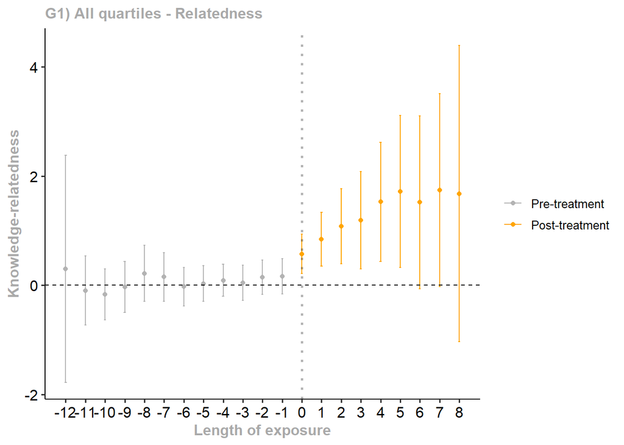

```r
Fig
```

Next, we repeat the same process for innovative performance (NoPatentsYearGUOtotal).

```r
# Simple Aggregation for Innovative Performance
example_attgt <- att_gt(
  yname = "NoPatentsYearGUOtotal",
  tname = "CurrentYear",
  idname = "id",
  gname = "first.treat",
  xformla = ~1,
  data = DataLong_Subs_sim,
  alp = .01
)

agg.simple <- aggte(example_attgt, type = "simple", na.rm = TRUE)
```

The overall effects on innovative performance are:

```r
summary(agg.simple)
```

```
##
## Call:
## aggte(MP = example_attgt, type = "simple", na.rm = TRUE)
##
## Reference: Callaway, Brantly and Pedro H.C. Sant'Anna.  "Difference-in-Differences with Multiple Time Periods." Journal of Econometrics, Vol. 225, No. 2, pp. 200-230, 2021. <https://doi.org/10.1016/j.jeconom.2020.12.001>, <https://arxiv.org/abs/1803.09015>
##
##
##    ATT    Std. Error     [ 99%  Conf. Int.]
##  18.14         3.326     9.5728     26.7071 *
##
##
## ---
## Signif. codes: `*' confidence band does not cover 0
##
## Control Group:  Never Treated,  Anticipation Periods:  0
## Estimation Method:  Doubly Robust
```

And the dynamic effects plot:

```r
# Dynamic Effects for Innovative Performance
agg.es <- aggte(example_attgt, type = "dynamic", na.rm = TRUE)
summary(agg.es)
```

```
##
## Call:
## aggte(MP = example_attgt, type = "dynamic", na.rm = TRUE)
##
## Reference: Callaway, Brantly and Pedro H.C. Sant'Anna.  "Difference-in-Differences with Multiple Time Periods." Journal of Econometrics, Vol. 225, No. 2, pp. 200-230, 2021. <https://doi.org/10.1016/j.jeconom.2020.12.001>, <https://arxiv.org/abs/1803.09015>
##
##
## Overall summary of ATT's based on event-study/dynamic aggregation:
##     ATT    Std. Error     [ 99%  Conf. Int.]
##  27.982        8.4066      6.328     49.6359 *
##
##
## Dynamic Effects:
##  Event time Estimate Std. Error [99% Simult.  Conf. Band]
##         -12  -0.7464     1.2341       -4.4138      2.9211
##         -11   1.3518     1.3716       -2.7242      5.4278
##         -10   0.6468     1.1760       -2.8481      4.1416
##          -9  -0.2512     0.8391       -2.7447      2.2423
##          -8   0.5535     0.7716       -1.7396      2.8466
##          -7  -0.1246     0.6442       -2.0390      1.7899
##          -6  -0.1549     0.5830       -1.8876      1.5777
##          -5   0.2728     0.5374       -1.3242      1.8698
##          -4   0.6244     0.5781       -1.0934      2.3422
##          -3   0.7835     0.5663       -0.8993      2.4662
##          -2   0.9849     0.5786       -0.7344      2.7043
##          -1   1.9840     0.6565        0.0330      3.9351 *
##           0   6.9626     1.5942        2.2250     11.7003 *
##           1  10.5710     3.5642       -0.0208     21.1628
##           2  16.7701     5.4188        0.6669     32.8733 *
##           3  17.5965     4.0450        5.5759     29.6171 *
##           4  29.3977     5.9573       11.6941     47.1012 *
##           5  34.0346     8.9269        7.5060     60.5632 *
##           6  32.4215    10.0947        2.4227     62.4204 *
##           7  43.8541    14.6756        0.2417     87.4664 *
##           8  60.2297    43.6130      -69.3772    189.8367
## ---
## Signif. codes: `*' confidence band does not cover 0
##
## Control Group:  Never Treated,  Anticipation Periods:  0
## Estimation Method:  Doubly Robust
```

```r
Fig <- ggdid(agg.es, title = "G2) All quartiles - Innovative performance") +
  theme(legend.position = "right") +
  ylab("Number of patents") +
  xlab("Length of exposure") +
  scale_color_manual(values = c("grey70", "saddlebrown"), labels = c("Pre-treatment", "Post-treatment")) +
  geom_vline(xintercept = 0, linetype = "dotted", color = "black", size = 1, alpha = 0.3)
```

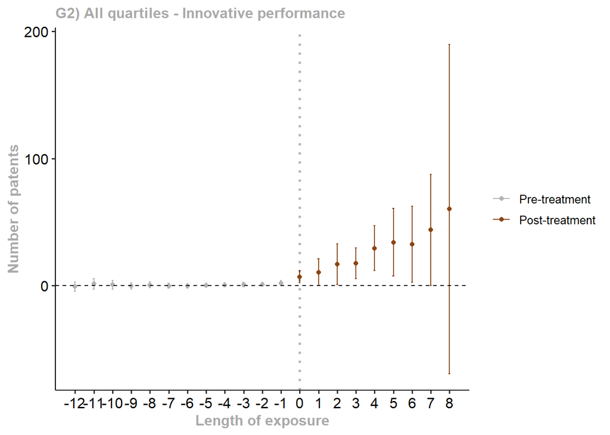

```r
Fig
```

#### 2.1.1.1. Moderating effects (Non-standard)

To investigate the moderating effects of **relatedness** on **innovative performance**, we’ll use a traditional DiD linear model for a more direct interpretation. First, we establish a baseline model for each of our two main variables without the moderator.

```r
# Create a binary post-treatment variable
DataLong_Subs_sim$post_treatment <- ifelse(
  DataLong_Subs_sim$CurrentYear >= DataLong_Subs_sim$first.treat &
  DataLong_Subs_sim$Group <= DataLong_Subs_sim$CurrentYear, 1, 0
)

# Basic DiD model for relatedness without the moderator
model <- lm(Relatedness_Cos2 ~ treat * post_treatment, data = DataLong_Subs_sim)
```

The results for relatedness are:

```r
summary(model)
```

```
##
## Call:
## lm(formula = Relatedness_Cos2 ~ treat * post_treatment, data = DataLong_Subs_sim)
##
## Residuals:
##     Min      1Q  Median      3Q     Max
## -15.265 -10.265  -1.265   7.735  43.320
##
## Coefficients:
##                      Estimate Std. Error t value Pr(>|t|)
## (Intercept)           12.0186     0.1147 104.794  < 2e-16 ***
## treat                  0.6618     0.1643   4.028 5.64e-05 ***
## post_treatment         1.2469     0.1925   6.477 9.51e-11 ***
## treat:post_treatment   1.3380     0.2729   4.904 9.45e-07 ***
## ---
## Signif. codes:  0 '***' 0.001 '**' 0.01 '*' 0.05 '.' 0.1 ' ' 1
##
## Residual standard error: 11.13 on 28819 degrees of freedom
##   (6373 observations deleted due to missingness)
## Multiple R-squared:  0.01034,    Adjusted R-squared:  0.01024
## F-statistic: 100.4 on 3 and 28819 DF,  p-value: < 2.2e-16
```

Next, we do the same for innovative performance:

```r
# Basic DiD model for innovative performance without the moderator
model <- lm(NoPatentsYearGUOtotal ~ treat * post_treatment, data = DataLong_Subs_sim)
```

```r
summary(model)
```

```
##
## Call:
## lm(formula = NoPatentsYearGUOtotal ~ treat * post_treatment,
##     data = DataLong_Subs_sim)
##
## Residuals:
##    Min     1Q Median     3Q    Max
## -124.9  -62.3  -53.8  -14.8 3853.1
##
## Coefficients:
##                      Estimate Std. Error t value Pr(>|t|)
## (Intercept)            57.821      1.862  31.048  < 2e-16 ***
## treat                   4.478      2.634   1.700   0.0891 .
## post_treatment         33.084      3.379   9.790  < 2e-16 ***
## treat:post_treatment   29.473      4.779   6.167 7.02e-10 ***
## ---
## Signif. codes:  0 '***' 0.001 '**' 0.01 '*' 0.05 '.' 0.1 ' ' 1
##
## Residual standard error: 206.1 on 35192 degrees of freedom
## Multiple R-squared:  0.01334,    Adjusted R-squared:  0.01326
## F-statistic: 158.6 on 3 and 35192 DF,  p-value: < 2.2e-16
```

Finally, we estimate a model with the interaction term to capture the moderating effect. The core moderating effect is represented by the interaction term treat:post_treatment:Relatedness_Cos2.

```r
# DiD model with Relatedness_Cos2 as a moderator
model_moderation <- lm(NoPatentsYearGUOtotal ~ treat * post_treatment * Relatedness_Cos2, data = DataLong_Subs_sim)
```

```r
summary(model_moderation)
```

```
##
## Call:
## lm(formula = NoPatentsYearGUOtotal ~ treat * post_treatment *
##     Relatedness_Cos2, data = DataLong_Subs_sim)
##
## Residuals:
##    Min     1Q Median     3Q    Max
## -422.4  -67.7  -13.9   18.2 3655.5
##
## Coefficients:
##                                       Estimate Std. Error t value Pr(>|t|)
## (Intercept)                             1.5153     3.1407   0.482  0.62947
## treat                                 -18.7609     4.5840  -4.093 4.28e-05 ***
## post_treatment                         -2.4439     5.3921  -0.453  0.65038
## Relatedness_Cos2                        6.1295     0.1917  31.973  < 2e-16 ***
## treat:post_treatment                  -21.9771     8.0202  -2.740  0.00614 **
## treat:Relatedness_Cos2                  1.9534     0.2762   7.073 1.55e-12 ***
## post_treatment:Relatedness_Cos2         1.0060     0.3144   3.199  0.00138 **
## treat:post_treatment:Relatedness_Cos2   1.9468     0.4548   4.281 1.87e-05 ***
## ---
## Signif. codes:  0 '***' 0.001 '**' 0.01 '*' 0.05 '.' 0.1 ' ' 1
##
## Residual standard error: 207.2 on 28815 degrees of freedom
##   (6373 observations deleted due to missingness)
## Multiple R-squared:  0.1601, Adjusted R-squared:  0.1599
## F-statistic: 784.9 on 7 and 28815 DF,  p-value: < 2.2e-16
```

### 2.1.2. Standardized - Relatedness and number of patents regardless of sector

We now re-estimate the effects for Relatedness_Cos2 and NoPatentsYearGUOtotal after standardizing their values. This process involves scaling the variables to have a mean of zero and a standard deviation of one.

```r
DataLong_Subs_sim_standard <- DataLong_Subs_sim
DataLong_Subs_sim_standard[, c("Relatedness_Cos2", "NoPatentsYearGUOtotal")] <-
  scale(DataLong_Subs_sim_standard[, c("Relatedness_Cos2", "NoPatentsYearGUOtotal")])

# Simple Aggregation for Relatedness (Standardized)
example_attgt <- att_gt(
  yname = "Relatedness_Cos2",
  tname = "CurrentYear",
  idname = "id",
  gname = "first.treat",
  xformla = ~1,
  data = DataLong_Subs_sim_standard,
  alp = .01
)

agg.simple <- aggte(example_attgt, type = "simple", na.rm = TRUE)
```

The overall treatment effect for standardized Relatedness_Cos2 is:

```r
summary(agg.simple)
```

```
##
## Call:
## aggte(MP = example_attgt, type = "simple", na.rm = TRUE)
##
## Reference: Callaway, Brantly and Pedro H.C. Sant'Anna.  "Difference-in-Differences with Multiple Time Periods." Journal of Econometrics, Vol. 225, No. 2, pp. 200-230, 2021. <https://doi.org/10.1016/j.jeconom.2020.12.001>, <https://arxiv.org/abs/1803.09015>
##
##
##     ATT    Std. Error     [ 99%  Conf. Int.]
##  0.0965        0.0174     0.0517      0.1413 *
##
##
## ---
## Signif. codes: `*' confidence band does not cover 0
##
## Control Group:  Never Treated,  Anticipation Periods:  0
## Estimation Method:  Doubly Robust
```

Next, we calculate the overall treatment effect for standardized NoPatentsYearGUOtotal.

```r
# Simple Aggregation for Innovative Performance (Standardized)
example_attgt <- att_gt(
  yname = "NoPatentsYearGUOtotal",
  tname = "CurrentYear",
  idname = "id",
  gname = "first.treat",
  xformla = ~1,
  data = DataLong_Subs_sim_standard,
  alp = .01
)

agg.simple <- aggte(example_attgt, type = "simple", na.rm = TRUE)
```

The overall treatment effect for standardized NoPatentsYearGUOtotal is:

```r
summary(agg.simple)
```

```
##
## Call:
## aggte(MP = example_attgt, type = "simple", na.rm = TRUE)
##
## Reference: Callaway, Brantly and Pedro H.C. Sant'Anna.  "Difference-in-Differences with Multiple Time Periods." Journal of Econometrics, Vol. 225, No. 2, pp. 200-230, 2021. <https://doi.org/10.1016/j.jeconom.2020.12.001>, <https://arxiv.org/abs/1803.09015>
##
##
##     ATT    Std. Error     [ 99%  Conf. Int.]
##  0.0874         0.017     0.0437      0.1311 *
##
##
## ---
## Signif. codes: `*' confidence band does not cover 0
##
## Control Group:  Never Treated,  Anticipation Periods:  0
## Estimation Method:  Doubly Robust
```

####2.1.2.1. Moderating effects (standardized)

We will now use a standard DiD approach to analyze the moderating effects with the standardized variables.

```r
# Create the Post-Treatment binary Variable (if not already created)
DataLong_Subs_sim_standard$post_treatment <- ifelse(
  DataLong_Subs_sim_standard$CurrentYear >= DataLong_Subs_sim_standard$first.treat &
  DataLong_Subs_sim_standard$Group <= DataLong_Subs_sim_standard$CurrentYear, 1, 0
)

# Basic DiD model for Relatedness (Standardized)
model <- lm(Relatedness_Cos2 ~ treat * post_treatment, data = DataLong_Subs_sim_standard)
```

The results for the standardized DiD model for Relatedness_Cos2 are:

```r
summary(model)
```

```
##
## Call:
## lm(formula = Relatedness_Cos2 ~ treat * post_treatment, data = DataLong_Subs_sim_standard)
##
## Residuals:
##     Min      1Q  Median      3Q     Max
## -1.3642 -0.9174 -0.1131  0.6912  3.8713
##
## Coefficients:
##                      Estimate Std. Error t value Pr(>|t|)
## (Intercept)          -0.09139    0.01025  -8.917  < 2e-16 ***
## treat                 0.05914    0.01468   4.028 5.64e-05 ***
## post_treatment        0.11143    0.01720   6.477 9.51e-11 ***
## treat:post_treatment  0.11958    0.02438   4.904 9.45e-07 ***
## ---
## Signif. codes:  0 '***' 0.001 '**' 0.01 '*' 0.05 '.' 0.1 ' ' 1
##
## Residual standard error: 0.9949 on 28819 degrees of freedom
##   (6373 observations deleted due to missingness)
## Multiple R-squared:  0.01034,    Adjusted R-squared:  0.01024
## F-statistic: 100.4 on 3 and 28819 DF,  p-value: < 2.2e-16
```

Next, we run the basic DiD model for standardized NoPatentsYearGUOtotal.

```r
# Basic DiD model for Innovative Performance (Standardized)
model <- lm(NoPatentsYearGUOtotal ~ treat * post_treatment, data = DataLong_Subs_sim_standard)
```

The results for the standardized DiD model for NoPatentsYearGUOtotal are:

```r
summary(model)
```

```
##
## Call:
## lm(formula = NoPatentsYearGUOtotal ~ treat * post_treatment,
##     data = DataLong_Subs_sim_standard)
##
## Residuals:
##     Min      1Q  Median      3Q     Max
## -0.6016 -0.3002 -0.2593 -0.0714 18.5670
##
## Coefficients:
##                       Estimate Std. Error t value Pr(>|t|)
## (Intercept)          -0.080776   0.008974  -9.001  < 2e-16 ***
## treat                 0.021576   0.012691   1.700   0.0891 .
## post_treatment        0.159419   0.016283   9.790  < 2e-16 ***
## treat:post_treatment  0.142023   0.023028   6.167 7.02e-10 ***
## ---
## Signif. codes:  0 '***' 0.001 '**' 0.01 '*' 0.05 '.' 0.1 ' ' 1
##
## Residual standard error: 0.9933 on 35192 degrees of freedom
## Multiple R-squared:  0.01334,    Adjusted R-squared:  0.01326
## F-statistic: 158.6 on 3 and 35192 DF,  p-value: < 2.2e-16
```

Finally, we estimate the moderating effects of standardized Relatedness_Cos2 on standardized NoPatentsYearGUOtotal. The effect of innovative performance is shown in the treat:post_treatment variable, while the moderating effect of relatedness is shown in the treat:post_treatment:Relatedness_Cos2 variable.

```r
# DiD model with standardized Relatedness_Cos2 as a moderator
model_moderation <- lm(NoPatentsYearGUOtotal ~ treat * post_treatment * Relatedness_Cos2, data = DataLong_Subs_sim_standard)
```

The results for the standardized moderating effects are:

```r
summary(model_moderation)
```

```
##
## Call:
## lm(formula = NoPatentsYearGUOtotal ~ treat * post_treatment *
##     Relatedness_Cos2, data = DataLong_Subs_sim_standard)
##
## Residuals:
##     Min      1Q  Median      3Q     Max
## -2.0354 -0.3265 -0.0670  0.0879 17.6145
##
## Coefficients:
##                                       Estimate Std. Error t value Pr(>|t|)
## (Intercept)                            0.03309    0.01033   3.204  0.00136 **
## treat                                  0.03235    0.01477   2.191  0.02847 *
## post_treatment                         0.05144    0.01729   2.975  0.00293 **
## Relatedness_Cos2                       0.33050    0.01034  31.973  < 2e-16 ***
## treat:post_treatment                   0.01644    0.02465   0.667  0.50476
## treat:Relatedness_Cos2                 0.10533    0.01489   7.073 1.55e-12 ***
## post_treatment:Relatedness_Cos2        0.05425    0.01695   3.199  0.00138 **
## treat:post_treatment:Relatedness_Cos2  0.10497    0.02452   4.281 1.87e-05 ***
## ---
## Signif. codes:  0 '***' 0.001 '**' 0.01 '*' 0.05 '.' 0.1 ' ' 1
##
## Residual standard error: 0.9983 on 28815 degrees of freedom
##   (6373 observations deleted due to missingness)
## Multiple R-squared:  0.1601, Adjusted R-squared:  0.1599
## F-statistic: 784.9 on 7 and 28815 DF,  p-value: < 2.2e-16
```

Next, we will proceed to section 2.2, where we’ll delve deeper into the analysis by measuring the effects across different sectors, providing a more granular understanding of how AI adoption impacts innovation based on technological proximity.

## 2.2. Measuring effects across sectors

In this section, we expand our analysis to measure the effects of AI introduction across different industry sectors. We first analyze the primary variables of the paper — **Relatedness** and **Innovative Performance** — and then evaluate the estimations for a broader set of variables.

```r
rm(list = ls())

# Load the main dataset and extra data file
DataLong_Subs_sim <- read.csv("Input_code/Matched_companies.csv", sep = ";", header = TRUE, dec = ",")
Extra_data <- read.csv("Input_code/Matched_companies_extra_data.csv")

# Merge the extra data for a more complete dataset
DataLong_Subs_sim <- left_join(DataLong_Subs_sim, Extra_data, by = c("id", "CurrentYear"))
rm(Extra_data)

# Calculate additional indicators related to subsidiaries and headquarters
DataLong_Subs_sim$Rate_granted_subs_rel_HQ <- DataLong_Subs_sim$n_granted_yes_subsidiaries / (DataLong_Subs_sim$n_granted_yes_HQ + DataLong_Subs_sim$n_granted_yes_subsidiaries)
DataLong_Subs_sim$Rate_success_subs <- DataLong_Subs_sim$n_granted_yes_subsidiaries / (DataLong_Subs_sim$n_granted_na_subsidiaries + DataLong_Subs_sim$n_granted_yes_subsidiaries)
DataLong_Subs_sim$Rate_granted_per_sub <- DataLong_Subs_sim$n_granted_yes_subsidiaries / (DataLong_Subs_sim$No_subs_extended)
DataLong_Subs_sim$Rate_granted_subs_rel_HQ_TOTAL <- DataLong_Subs_sim$NoPatentsYearALLSubs / (DataLong_Subs_sim$NoPatentsYearALLSubs + DataLong_Subs_sim$NoPatentsYearGUOtotal)
DataLong_Subs_sim$Rate_success_HQ <- DataLong_Subs_sim$n_granted_yes_HQ / (DataLong_Subs_sim$n_granted_na_HQ + DataLong_Subs_sim$n_granted_yes_HQ)
DataLong_Subs_sim$Patent_productivity <- DataLong_Subs_sim$No_new_PatentsYearGUOalone / DataLong_Subs_sim$RandD_Year
DataLong_Subs_sim$Patent_output_per_employee <- DataLong_Subs_sim$No_new_PatentsYearGUOalone / DataLong_Subs_sim$number_of_employees

# Replace infinite or NaN values with NA
DataLong_Subs_sim <- DataLong_Subs_sim %>%
  mutate(across(
    c("Rate_success_subs", "Rate_success_HQ", "Patent_productivity", "Patent_output_per_employee"),
    ~ ifelse(is.nan(.), NA, .)
  )) %>%
  mutate(across(
    c("Patent_productivity", "Patent_output_per_employee", "Rate_granted_per_sub"),
    ~ ifelse(is.infinite(.), NA, .)
  ))

# Insert the distance measure calculated in section 1
CategoriesNace <- read.csv("Output_code/Data/Distance_measure.csv", header = TRUE)
CategoriesNace <- CategoriesNace[, c("Nace_4d", "Quartile_top9")]
names(CategoriesNace) <- c("Nace_4d", "Quartile")
CategoriesNace$Nace_4d <- as.character(CategoriesNace$Nace_4d)
DataLong_Subs_sim$Nace_4d <- as.character(DataLong_Subs_sim$Nace_4d)
DataLong_Subs_sim <- left_join(DataLong_Subs_sim, CategoriesNace, by = "Nace_4d")

# Handle any remaining missing quartile values
DataLong_Subs_sim$Quartile[is.na(DataLong_Subs_sim$Quartile)] <- "Bottom"

# Split data into groups based on quartiles for sectoral analysis
DataLong_Subs_sim_group1 <- DataLong_Subs_sim[DataLong_Subs_sim$Quartile == "Top", ]
DataLong_Subs_sim_group2 <- DataLong_Subs_sim[DataLong_Subs_sim$Quartile == "IQR", ]
DataLong_Subs_sim_group3 <- DataLong_Subs_sim[DataLong_Subs_sim$Quartile == "Bottom", ]

# Define a function to calculate confidence intervals and significance
calculate_ci_and_significance <- function(att, se, group, variable_name) {
  # Confidence intervals at different significance levels
  ci_90_low <- att - 1.645 * se
  ci_90_high <- att + 1.645 * se

  ci_95_low <- att - 1.96 * se
  ci_95_high <- att + 1.96 * se

  ci_99_low <- att - 2.576 * se
  ci_99_high <- att + 2.576 * se

  # Determine the highest significance level
  significance <- ""
  if (ci_90_low > 0 | ci_90_high < 0) {
    significance <- "*"
  }
  if (ci_95_low > 0 | ci_95_high < 0) {
    significance <- "**"
  }
  if (ci_99_low > 0 | ci_99_high < 0) {
    significance <- "***"
  }
  if (!(ci_90_low > 0 | ci_90_high < 0)) {
    significance <- ""
  }

  # Create a dataframe to store the results
  results_df <- data.frame(
    ATT = att,
    Std_Error = se,
    CI_90_Low = ci_90_low,
    CI_90_High = ci_90_high,
    CI_95_Low = ci_95_low,
    CI_95_High = ci_95_high,
    CI_99_Low = ci_99_low,
    CI_99_High = ci_99_high,
    Significance = significance,
    Group = group,
    Variable = variable_name
  )

  return(results_df)
}

# Define fixed variables for the `did` functions
tname = "CurrentYear"
idname = "id"
gname = "first.treat"

# Define the groups and variables for analysis
groups = c("DataLong_Subs_sim_group1", "DataLong_Subs_sim_group2", "DataLong_Subs_sim_group3")
variables = c(
  "Relatedness_Cos2",
  "NoPatentsYearGUOtotal",
  "Specializations_Number",
  "UniqueCodes",
  "UniqueSubclass",
  "Herfindahl",
  "Shannon",
  "AIcodes",
  "No_AI_PatentsYearGUOtotal"
)
```

### 2.2.1. Calculate the effects (Non-standardized) for Relatedness and Innovative Performance

We begin by estimating the non-standardized effects on Relatedness (Relatedness_Cos2) for the closest group of companies (Quartile 1 - Top).

#### 2.2.1.1. Relatedness

First, for the top quartile of companies closest to AI.

```r
variable_n = 1
n_group = 1
group = "DataLong_Subs_sim_group1"
variable_name <- variables[variable_n]

# Estimate ATT for the top quartile
estim_attgt <- att_gt(tname = tname, idname = idname, gname = gname,
                      yname = variables[variable_n], data = DataLong_Subs_sim_group1)
agg.simple <- aggte(estim_attgt, type = "simple", na.rm = TRUE)

att <- agg.simple$overall.att
se <- agg.simple$overall.se

results_df <- calculate_ci_and_significance(att, se, group, variable_name)

# Dynamic events study
agg.es <- aggte(estim_attgt, type = "dynamic", na.rm = TRUE)
Fig <- ggdid(agg.es, title = "G3) Q1 - Relatedness") +
  theme(legend.position = "right") +
  ylab("Estimated effect on relatedness") +
  xlab("Length of exposure") +
  scale_color_manual(values = c("grey70", "steelblue3")) +
  labs(color = "Treatment") +
  geom_vline(xintercept = 0, linetype = "dotted", color = "black", size = 1, alpha = 0.3)
```

The overall effect for the top quartile is:

```r
summary(agg.simple)
```

```
##
## Call:
## aggte(MP = estim_attgt, type = "simple", na.rm = TRUE)
##
## Reference: Callaway, Brantly and Pedro H.C. Sant'Anna.  "Difference-in-Differences with Multiple Time Periods." Journal of Econometrics, Vol. 225, No. 2, pp. 200-230, 2021. <https://doi.org/10.1016/j.jeconom.2020.12.001>, <https://arxiv.org/abs/1803.09015>
##
##
##     ATT    Std. Error     [ 95%  Conf. Int.]
##  1.7882        0.3682     1.0666      2.5098 *
##
##
## ---
## Signif. codes: `*' confidence band does not cover 0
##
## Control Group:  Never Treated,  Anticipation Periods:  0
## Estimation Method:  Doubly Robust
```

The corresponding event study plot shows the dynamic effects over time:

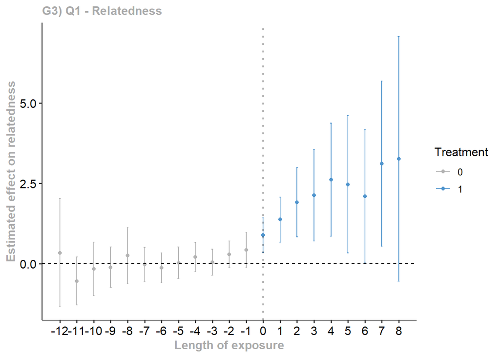

```r
Fig
```

The confidence intervals and significance level are:

```r
knitr::kable(results_df)
```

| ATT | Std_Error | CI_90_Low | CI_90_High | CI_95_Low | CI_95_High | CI_99_Low | CI_99_High | Significance | Group | Variable |
| --- | --- | --- | --- | --- | --- | --- | --- | --- | --- | --- |
| 1.788202 | 0.3681625 | 1.182574 | 2.393829 | 1.066603 | 2.5098 | 0.839815 | 2.736588 | *** | DataLong_Subs_sim_group1 | Relatedness_Cos2 |

Next, for the Interquartile Range (IQR) group.

```r
n_group = 2
group = "DataLong_Subs_sim_group2"

estim_attgt <- att_gt(tname = tname, idname = idname, gname = gname,
                      yname = variables[variable_n], data = DataLong_Subs_sim_group2)
agg.simple <- aggte(estim_attgt, type = "simple", na.rm = TRUE)

att <- agg.simple$overall.att
se <- agg.simple$overall.se

results_new <- calculate_ci_and_significance(att, se, group, variable_name)
results_df <- rbind(results_df, results_new)

agg.es <- aggte(estim_attgt, type = "dynamic", na.rm = TRUE)
Fig <- ggdid(agg.es, title = "G4) IQR - Relatedness") +
  theme(legend.position = "right") +
  ylab("Estimated effect on relatedness") +
  xlab("Length of exposure") +
  scale_color_manual(values = c("grey70", "green4")) +
  labs(color = "Treatment") +
  geom_vline(xintercept = 0, linetype = "dotted", color = "black", size = 1, alpha = 0.3)
```

The overall effect for the IQR is:

```r
summary(agg.simple)
```

```
##
## Call:
## aggte(MP = estim_attgt, type = "simple", na.rm = TRUE)
##
## Reference: Callaway, Brantly and Pedro H.C. Sant'Anna.  "Difference-in-Differences with Multiple Time Periods." Journal of Econometrics, Vol. 225, No. 2, pp. 200-230, 2021. <https://doi.org/10.1016/j.jeconom.2020.12.001>, <https://arxiv.org/abs/1803.09015>
##
##
##     ATT    Std. Error     [ 95%  Conf. Int.]
##  0.6318        0.2874     0.0684      1.1951 *
##
##
## ---
## Signif. codes: `*' confidence band does not cover 0
##
## Control Group:  Never Treated,  Anticipation Periods:  0
## Estimation Method:  Doubly Robust
```

And the dynamic effects plot:

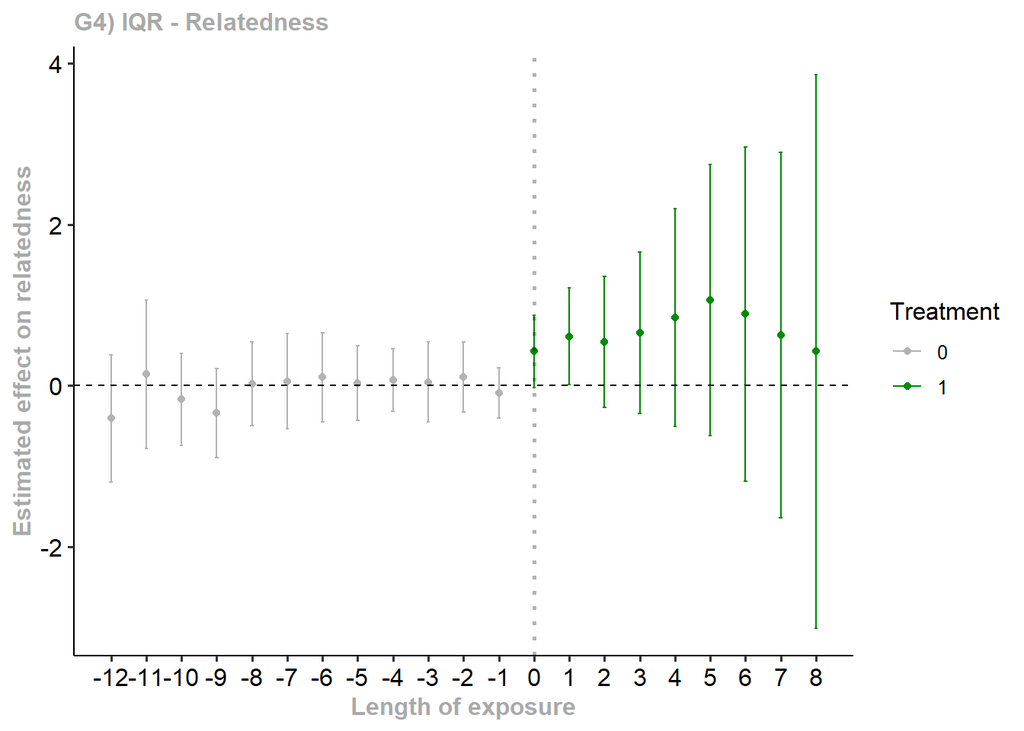

```r
Fig
```

The confidence intervals and significance level are:

```r
knitr::kable(results_df)
```

| ATT | Std_Error | CI_90_Low | CI_90_High | CI_95_Low | CI_95_High | CI_99_Low | CI_99_High | Significance | Group | Variable |
| --- | --- | --- | --- | --- | --- | --- | --- | --- | --- | --- |
| 1.7882017 | 0.3681625 | 1.1825743 | 2.393829 | 1.0666032 | 2.509800 | 0.8398150 | 2.736588 | *** | DataLong_Subs_sim_group1 | Relatedness_Cos2 |
| 0.6317646 | 0.2874400 | 0.1589258 | 1.104603 | 0.0683822 | 1.195147 | -0.1086808 | 1.372210 | ** | DataLong_Subs_sim_group2 | Relatedness_Cos2 |

Finally, for the lowest quartile (Q4).

```r
n_group = 3
group = "DataLong_Subs_sim_group3"

estim_attgt <- att_gt(tname = tname, idname = idname, gname = gname,
                      yname = variables[variable_n], data = DataLong_Subs_sim_group3)
agg.simple <- aggte(estim_attgt, type = "simple", na.rm = TRUE)

att <- agg.simple$overall.att
se <- agg.simple$overall.se

results_new <- calculate_ci_and_significance(att, se, group, variable_name)
results_df <- rbind(results_df, results_new)

agg.es <- aggte(estim_attgt, type = "dynamic", na.rm = TRUE)
Fig <- ggdid(agg.es, title = "G5) Q4 - Relatedness") +
  theme(legend.position = "right") +
  ylab("Estimated effect on relatedness") +
  xlab("Length of exposure") +
  scale_color_manual(values = c("grey70", "red4")) +
  labs(color = "Treatment") +
  geom_vline(xintercept = 0, linetype = "dotted", color = "black", size = 1, alpha = 0.3)
```

The overall effect for Q4 is:

```r
summary(agg.simple)
```

```
##
## Call:
## aggte(MP = estim_attgt, type = "simple", na.rm = TRUE)
##
## Reference: Callaway, Brantly and Pedro H.C. Sant'Anna.  "Difference-in-Differences with Multiple Time Periods." Journal of Econometrics, Vol. 225, No. 2, pp. 200-230, 2021. <https://doi.org/10.1016/j.jeconom.2020.12.001>, <https://arxiv.org/abs/1803.09015>
##
##
##     ATT    Std. Error     [ 95%  Conf. Int.]
##  0.6172        0.3595    -0.0874      1.3217
##
##
## ---
## Signif. codes: `*' confidence band does not cover 0
##
## Control Group:  Never Treated,  Anticipation Periods:  0
## Estimation Method:  Doubly Robust
```

And the dynamic effects plot:

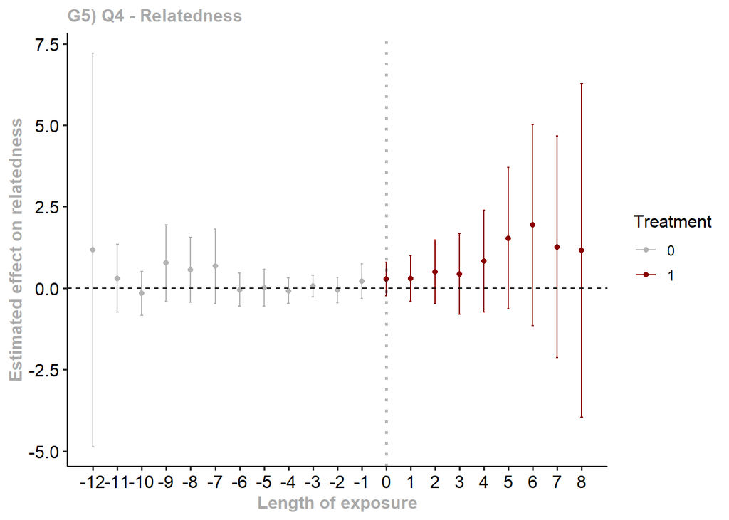

```r
Fig
```

The confidence intervals and significance level are:

```r
knitr::kable(results_df)
```

| ATT | Std_Error | CI_90_Low | CI_90_High | CI_95_Low | CI_95_High | CI_99_Low | CI_99_High | Significance | Group | Variable |
| --- | --- | --- | --- | --- | --- | --- | --- | --- | --- | --- |
| 1.7882017 | 0.3681625 | 1.1825743 | 2.393829 | 1.0666032 | 2.509800 | 0.8398150 | 2.736588 | *** | DataLong_Subs_sim_group1 | Relatedness_Cos2 |
| 0.6317646 | 0.2874400 | 0.1589258 | 1.104603 | 0.0683822 | 1.195147 | -0.1086808 | 1.372210 | ** | DataLong_Subs_sim_group2 | Relatedness_Cos2 |
| 0.6171934 | 0.3594716 | 0.0258626 | 1.208524 | -0.0873709 | 1.321758 | -0.3088054 | 1.543192 | * | DataLong_Subs_sim_group3 | Relatedness_Cos2 |

#### 2.2.1.2. Innovative performance

We follow the same procedure for Innovative Performance (NoPatentsYearGUOtotal), starting with the closest group (Q1).

```r
variable_n = 2
n_group = 1
group = "DataLong_Subs_sim_group1"
variable_name <- variables[variable_n]

estim_attgt <- att_gt(tname = tname, idname = idname, gname = gname,
                      yname = variables[variable_n], data = DataLong_Subs_sim_group1)
agg.simple <- aggte(estim_attgt, type = "simple", na.rm = TRUE)

att <- agg.simple$overall.att
se <- agg.simple$overall.se

results_new <- calculate_ci_and_significance(att, se, group, variable_name)
results_df <- rbind(results_df, results_new)

agg.es <- aggte(estim_attgt, type = "dynamic", na.rm = TRUE)
Fig <- ggdid(agg.es, title = "G6) Q1 - Innovative performance") +
  theme(legend.position = "right") +
  ylab("Estimated effect on number of patents") +
  xlab("Length of exposure") +
  scale_color_manual(values = c("grey70", "steelblue3")) +
  labs(color = "Treatment") +
  geom_vline(xintercept = 0, linetype = "dotted", color = "black", size = 1, alpha = 0.3)
```

The overall effect for the top quartile is:

```r
summary(agg.simple)
```

```
##
## Call:
## aggte(MP = estim_attgt, type = "simple", na.rm = TRUE)
##
## Reference: Callaway, Brantly and Pedro H.C. Sant'Anna.  "Difference-in-Differences with Multiple Time Periods." Journal of Econometrics, Vol. 225, No. 2, pp. 200-230, 2021. <https://doi.org/10.1016/j.jeconom.2020.12.001>, <https://arxiv.org/abs/1803.09015>
##
##
##      ATT    Std. Error     [ 95%  Conf. Int.]
##  22.2329        6.1719    10.1362     34.3296 *
##
##
## ---
## Signif. codes: `*' confidence band does not cover 0
##
## Control Group:  Never Treated,  Anticipation Periods:  0
## Estimation Method:  Doubly Robust
```

And the dynamic effects plot:

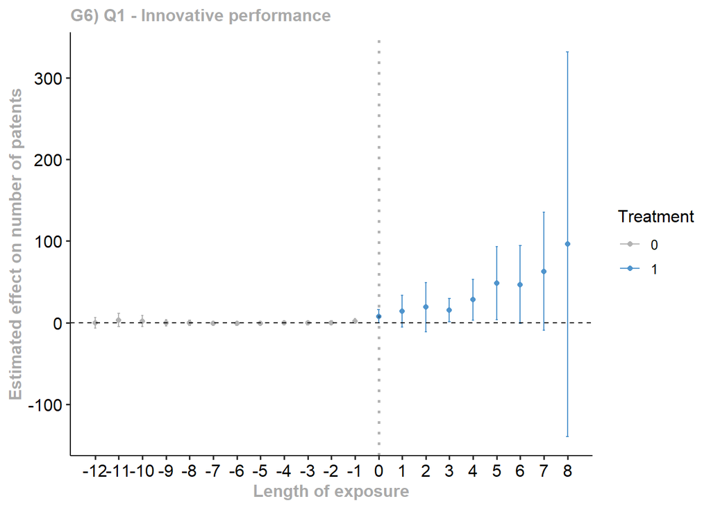

```r
Fig
```

The confidence intervals and significance level are:

```r
knitr::kable(results_df)
```

| ATT | Std_Error | CI_90_Low | CI_90_High | CI_95_Low | CI_95_High | CI_99_Low | CI_99_High | Significance | Group | Variable |
| --- | --- | --- | --- | --- | --- | --- | --- | --- | --- | --- |
| 1.7882017 | 0.3681625 | 1.1825743 | 2.393829 | 1.0666032 | 2.509800 | 0.8398150 | 2.736588 | *** | DataLong_Subs_sim_group1 | Relatedness_Cos2 |
| 0.6317646 | 0.2874400 | 0.1589258 | 1.104603 | 0.0683822 | 1.195147 | -0.1086808 | 1.372210 | ** | DataLong_Subs_sim_group2 | Relatedness_Cos2 |
| 0.6171934 | 0.3594716 | 0.0258626 | 1.208524 | -0.0873709 | 1.321758 | -0.3088054 | 1.543192 | * | DataLong_Subs_sim_group3 | Relatedness_Cos2 |
| 22.2329187 | 6.1718888 | 12.0801616 | 32.385676 | 10.1360166 | 34.329821 | 6.3341330 | 38.131704 | *** | DataLong_Subs_sim_group1 | NoPatentsYearGUOtotal |

For the Interquartile Range (IQR) group:

```r
n_group = 2
group = "DataLong_Subs_sim_group2"

estim_attgt <- att_gt(tname = tname, idname = idname, gname = gname,
                      yname = variables[variable_n], data = DataLong_Subs_sim_group2)
agg.simple <- aggte(estim_attgt, type = "simple", na.rm = TRUE)

att <- agg.simple$overall.att
se <- agg.simple$overall.se

results_new <- calculate_ci_and_significance(att, se, group, variable_name)
results_df <- rbind(results_df, results_new)

agg.es <- aggte(estim_attgt, type = "dynamic", na.rm = TRUE)
Fig <- ggdid(agg.es, title = "G7) IQR - Innovative performance") +
  theme(legend.position = "right") +
  ylab("Estimated effect on number of patents") +
  xlab("Length of exposure") +
  scale_color_manual(values = c("grey70", "green4")) +
  labs(color = "Treatment") +
  geom_vline(xintercept = 0, linetype = "dotted", color = "black", size = 1, alpha = 0.3)
```

The overall effect for the IQR is:

```r
summary(agg.simple)
```

```
##
## Call:
## aggte(MP = estim_attgt, type = "simple", na.rm = TRUE)
##
## Reference: Callaway, Brantly and Pedro H.C. Sant'Anna.  "Difference-in-Differences with Multiple Time Periods." Journal of Econometrics, Vol. 225, No. 2, pp. 200-230, 2021. <https://doi.org/10.1016/j.jeconom.2020.12.001>, <https://arxiv.org/abs/1803.09015>
##
##
##      ATT    Std. Error     [ 95%  Conf. Int.]
##  11.5939        3.5936     4.5507     18.6372 *
##
##
## ---
## Signif. codes: `*' confidence band does not cover 0
##
## Control Group:  Never Treated,  Anticipation Periods:  0
## Estimation Method:  Doubly Robust
```

And the dynamic effects plot:

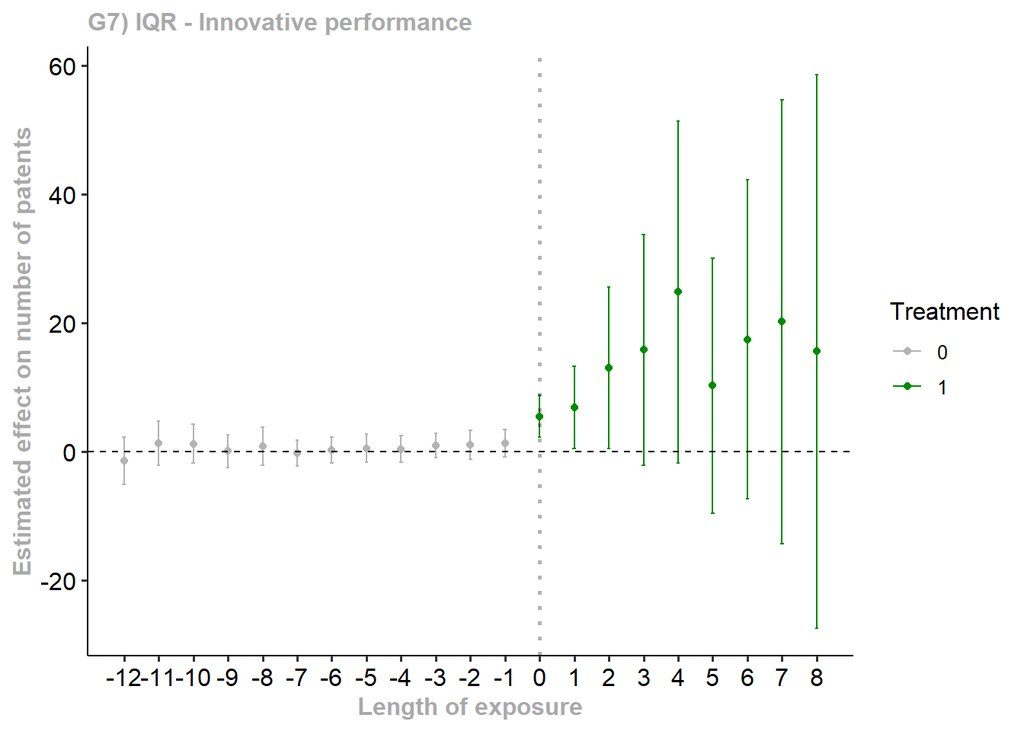

```r
Fig
```

The confidence intervals and significance level are:

```r
knitr::kable(results_df)
```

| ATT | Std_Error | CI_90_Low | CI_90_High | CI_95_Low | CI_95_High | CI_99_Low | CI_99_High | Significance | Group | Variable |
| --- | --- | --- | --- | --- | --- | --- | --- | --- | --- | --- |
| 1.7882017 | 0.3681625 | 1.1825743 | 2.393829 | 1.0666032 | 2.509800 | 0.8398150 | 2.736588 | *** | DataLong_Subs_sim_group1 | Relatedness_Cos2 |
| 0.6317646 | 0.2874400 | 0.1589258 | 1.104603 | 0.0683822 | 1.195147 | -0.1086808 | 1.372210 | ** | DataLong_Subs_sim_group2 | Relatedness_Cos2 |
| 0.6171934 | 0.3594716 | 0.0258626 | 1.208524 | -0.0873709 | 1.321758 | -0.3088054 | 1.543192 | * | DataLong_Subs_sim_group3 | Relatedness_Cos2 |
| 22.2329187 | 6.1718888 | 12.0801616 | 32.385676 | 10.1360166 | 34.329821 | 6.3341330 | 38.131704 | *** | DataLong_Subs_sim_group1 | NoPatentsYearGUOtotal |
| 11.5939234 | 3.5935523 | 5.6825298 | 17.505317 | 4.5505608 | 18.637286 | 2.3369325 | 20.850914 | *** | DataLong_Subs_sim_group2 | NoPatentsYearGUOtotal |

Finally, for the lowest quartile (Q4):

```r
n_group = 3
group = "DataLong_Subs_sim_group3"

estim_attgt <- att_gt(tname = tname, idname = idname, gname = gname,
                      yname = variables[variable_n], data = DataLong_Subs_sim_group3)
agg.simple <- aggte(estim_attgt, type = "simple", na.rm = TRUE)

att <- agg.simple$overall.att
se <- agg.simple$overall.se

results_new <- calculate_ci_and_significance(att, se, group, variable_name)
results_df <- rbind(results_df, results_new)

agg.es <- aggte(estim_attgt, type = "dynamic", na.rm = TRUE)
Fig <- ggdid(agg.es, title = "G8) Q4 - Innovative performance") +
  theme(legend.position = "right") +
  ylab("Estimated effect on number of patents") +
  xlab("Length of exposure") +
  scale_color_manual(values = c("grey70", "red4")) +
  labs(color = "Treatment") +
  geom_vline(xintercept = 0, linetype = "dotted", color = "black", size = 1, alpha = 0.3)
```

The overall effect for Q4 is:

```r
summary(agg.simple)
```

```
##
## Call:
## aggte(MP = estim_attgt, type = "simple", na.rm = TRUE)
##
## Reference: Callaway, Brantly and Pedro H.C. Sant'Anna.  "Difference-in-Differences with Multiple Time Periods." Journal of Econometrics, Vol. 225, No. 2, pp. 200-230, 2021. <https://doi.org/10.1016/j.jeconom.2020.12.001>, <https://arxiv.org/abs/1803.09015>
##
##
##      ATT    Std. Error     [ 95%  Conf. Int.]
##  22.2491        6.4048     9.6958     34.8023 *
##
##
## ---
## Signif. codes: `*' confidence band does not cover 0
##
## Control Group:  Never Treated,  Anticipation Periods:  0
## Estimation Method:  Doubly Robust
```

And the dynamic effects plot:

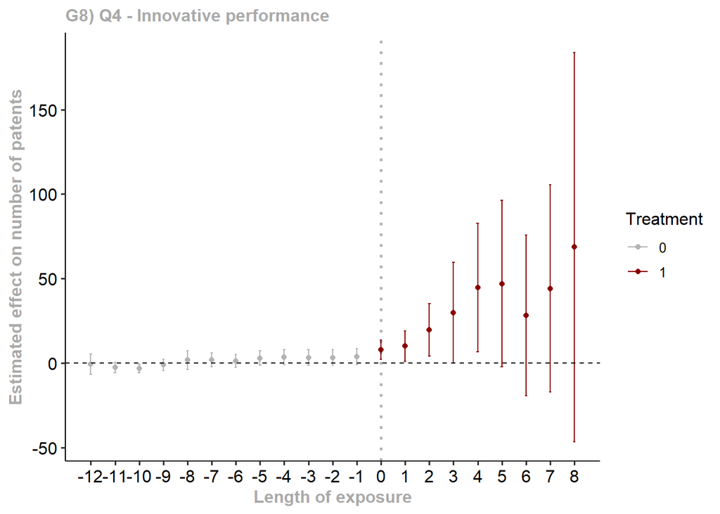

```r
Fig
```

The confidence intervals and significance level are:

```r
knitr::kable(results_df)
```

| ATT | Std_Error | CI_90_Low | CI_90_High | CI_95_Low | CI_95_High | CI_99_Low | CI_99_High | Significance | Group | Variable |
| --- | --- | --- | --- | --- | --- | --- | --- | --- | --- | --- |
| 1.7882017 | 0.3681625 | 1.1825743 | 2.393829 | 1.0666032 | 2.509800 | 0.8398150 | 2.736588 | *** | DataLong_Subs_sim_group1 | Relatedness_Cos2 |
| 0.6317646 | 0.2874400 | 0.1589258 | 1.104603 | 0.0683822 | 1.195147 | -0.1086808 | 1.372210 | ** | DataLong_Subs_sim_group2 | Relatedness_Cos2 |
| 0.6171934 | 0.3594716 | 0.0258626 | 1.208524 | -0.0873709 | 1.321758 | -0.3088054 | 1.543192 | * | DataLong_Subs_sim_group3 | Relatedness_Cos2 |
| 22.2329187 | 6.1718888 | 12.0801616 | 32.385676 | 10.1360166 | 34.329821 | 6.3341330 | 38.131704 | *** | DataLong_Subs_sim_group1 | NoPatentsYearGUOtotal |
| 11.5939234 | 3.5935523 | 5.6825298 | 17.505317 | 4.5505608 | 18.637286 | 2.3369325 | 20.850914 | *** | DataLong_Subs_sim_group2 | NoPatentsYearGUOtotal |
| 22.2490594 | 6.4048385 | 11.7131000 | 32.785019 | 9.6955759 | 34.802543 | 5.7501954 | 38.747923 | *** | DataLong_Subs_sim_group3 | NoPatentsYearGUOtotal |

#### 2.2.1.3. Remaining variables

We do the same for the remaining variables, always doing the calculations just by changing the variable_n and the n_group (which goes here from 1 to 3, 1 always being the 1Q, 2 the IQR, and 3 the 4Q), and appending the estimations to the existing **results_df**. As no dynamic effects are considered for the remaining variables, just the overall effects are summarized below.

```
## [1] DataLong_Subs_sim_group1
```

```
## [1] DataLong_Subs_sim_group2
```

```
## [1] DataLong_Subs_sim_group3
```

```
## [1] DataLong_Subs_sim_group1
```

```
## [1] DataLong_Subs_sim_group2
```

```
## [1] DataLong_Subs_sim_group3
```

```
## [1] DataLong_Subs_sim_group1
```

```
## [1] DataLong_Subs_sim_group2
```

```
## [1] DataLong_Subs_sim_group3
```

```
## [1] DataLong_Subs_sim_group1
```

```
## [1] DataLong_Subs_sim_group2
```

```
## [1] DataLong_Subs_sim_group3
```

```
## [1] DataLong_Subs_sim_group1
```

```
## [1] DataLong_Subs_sim_group2
```

```
## [1] DataLong_Subs_sim_group3
```

```
## [1] DataLong_Subs_sim_group1
```

```
## [1] DataLong_Subs_sim_group2
```

```
## [1] DataLong_Subs_sim_group3
```

The results are:

```r
knitr::kable(results_df)
```

| ATT | Std_Error | CI_90_Low | CI_90_High | CI_95_Low | CI_95_High | CI_99_Low | CI_99_High | Significance | Group | Variable |
| --- | --- | --- | --- | --- | --- | --- | --- | --- | --- | --- |
| 1.7882017 | 0.3681625 | 1.1825743 | 2.3938290 | 1.0666032 | 2.5098002 | 0.8398150 | 2.7365883 | *** | DataLong_Subs_sim_group1 | Relatedness_Cos2 |
| 0.6317646 | 0.2874400 | 0.1589258 | 1.1046034 | 0.0683822 | 1.1951470 | -0.1086808 | 1.3722100 | ** | DataLong_Subs_sim_group2 | Relatedness_Cos2 |
| 0.6171934 | 0.3594716 | 0.0258626 | 1.2085242 | -0.0873709 | 1.3217577 | -0.3088054 | 1.5431922 | * | DataLong_Subs_sim_group3 | Relatedness_Cos2 |
| 22.2329187 | 6.1718888 | 12.0801616 | 32.3856759 | 10.1360166 | 34.3298208 | 6.3341330 | 38.1317044 | *** | DataLong_Subs_sim_group1 | NoPatentsYearGUOtotal |
| 11.5939234 | 3.5935523 | 5.6825298 | 17.5053170 | 4.5505608 | 18.6372859 | 2.3369325 | 20.8509142 | *** | DataLong_Subs_sim_group2 | NoPatentsYearGUOtotal |
| 22.2490594 | 6.4048385 | 11.7131000 | 32.7850188 | 9.6955759 | 34.8025430 | 5.7501954 | 38.7479235 | *** | DataLong_Subs_sim_group3 | NoPatentsYearGUOtotal |
| 1.2680454 | 0.2569696 | 0.8453304 | 1.6907603 | 0.7643850 | 1.7717058 | 0.6060917 | 1.9299990 | *** | DataLong_Subs_sim_group1 | Specializations_Number |
| 1.1076042 | 0.2803850 | 0.6463709 | 1.5688375 | 0.5580496 | 1.6571588 | 0.3853324 | 1.8298759 | *** | DataLong_Subs_sim_group2 | Specializations_Number |
| 1.5061032 | 0.4936949 | 0.6939750 | 2.3182314 | 0.5384611 | 2.4737453 | 0.2343450 | 2.7778613 | *** | DataLong_Subs_sim_group3 | Specializations_Number |
| 0.2206835 | 0.0486252 | 0.1406951 | 0.3006719 | 0.1253781 | 0.3159889 | 0.0954250 | 0.3459420 | *** | DataLong_Subs_sim_group1 | UniqueCodes |
| 0.1523731 | 0.0563235 | 0.0597210 | 0.2450252 | 0.0419791 | 0.2627671 | 0.0072838 | 0.2974624 | *** | DataLong_Subs_sim_group2 | UniqueCodes |
| 0.1395612 | 0.0761590 | 0.0142796 | 0.2648428 | -0.0097105 | 0.2888329 | -0.0566245 | 0.3357468 | * | DataLong_Subs_sim_group3 | UniqueCodes |
| 2.9838379 | 0.7085988 | 1.8181928 | 4.1494829 | 1.5949842 | 4.3726916 | 1.1584873 | 4.8091884 | *** | DataLong_Subs_sim_group1 | UniqueSubclass |
| 2.6335605 | 0.5963297 | 1.6525981 | 3.6145229 | 1.4647543 | 3.8023668 | 1.0974152 | 4.1697059 | *** | DataLong_Subs_sim_group2 | UniqueSubclass |
| 3.7641852 | 0.8708945 | 2.3315637 | 5.1968067 | 2.0572319 | 5.4711385 | 1.5207608 | 6.0076096 | *** | DataLong_Subs_sim_group3 | UniqueSubclass |
| -0.0398610 | 0.0114898 | -0.0587617 | -0.0209603 | -0.0623809 | -0.0173410 | -0.0694586 | -0.0102633 | *** | DataLong_Subs_sim_group1 | Herfindahl |
| -0.0172927 | 0.0083413 | -0.0310140 | -0.0035713 | -0.0336415 | -0.0009438 | -0.0387797 | 0.0041944 | ** | DataLong_Subs_sim_group2 | Herfindahl |
| -0.0111112 | 0.0103599 | -0.0281533 | 0.0059309 | -0.0314167 | 0.0091943 | -0.0377984 | 0.0155760 |  | DataLong_Subs_sim_group3 | Herfindahl |
| 0.1802909 | 0.0421094 | 0.1110209 | 0.2495608 | 0.0977565 | 0.2628253 | 0.0718171 | 0.2887646 | *** | DataLong_Subs_sim_group1 | Shannon |
| 0.1036677 | 0.0305236 | 0.0534564 | 0.1538791 | 0.0438414 | 0.1634940 | 0.0250389 | 0.1822966 | *** | DataLong_Subs_sim_group2 | Shannon |
| 0.1065028 | 0.0455986 | 0.0314931 | 0.1815125 | 0.0171295 | 0.1958761 | -0.0109592 | 0.2239649 | ** | DataLong_Subs_sim_group3 | Shannon |
| 0.4925824 | 0.0409959 | 0.4251442 | 0.5600206 | 0.4122305 | 0.5729343 | 0.3869770 | 0.5981877 | *** | DataLong_Subs_sim_group1 | AIcodes |
| 0.2515668 | 0.0345643 | 0.1947086 | 0.3084250 | 0.1838209 | 0.3193128 | 0.1625293 | 0.3406043 | *** | DataLong_Subs_sim_group2 | AIcodes |
| 0.1826875 | 0.0405868 | 0.1159223 | 0.2494527 | 0.1031374 | 0.2622375 | 0.0781360 | 0.2872390 | *** | DataLong_Subs_sim_group3 | AIcodes |

## 2.3. Contrasting granted versus non-granted

Now, let’s compare the effects of AI adoption for companies that were granted at least one AI patent with those that were not. This section helps to distinguish between the simple act of applying for an AI patent and the actual success of receiving one.

We will focus exclusively on non-standardized values

### 2.3.1. Non-granted AI Patents

In this subsection, we define the treated group as companies that applied for AI patents but never had any granted (i.e., total_granted_ai == 0). The control group consists of companies that did not apply for any AI patents at all (treat == 0). This allows us to isolate the effects of an unsuccessful attempt at AI innovation.

```r
rm(list=ls())

DataLong_Subs_sim <- read.csv("Input_code/Matched_companies.csv", sep = ";", header = TRUE, dec = ",")
Extra_data <- read.csv("Input_code/Matched_companies_extra_data.csv")
DataLong_Subs_sim <- left_join(DataLong_Subs_sim, Extra_data, by = c("id", "CurrentYear"))
rm(Extra_data)

# Calculate additional indicators and clean data
DataLong_Subs_sim$Rate_granted_subs_rel_HQ <- DataLong_Subs_sim$n_granted_yes_subsidiaries/(DataLong_Subs_sim$n_granted_yes_HQ+DataLong_Subs_sim$n_granted_yes_subsidiaries)
DataLong_Subs_sim$Rate_success_subs <- DataLong_Subs_sim$n_granted_yes_subsidiaries/(DataLong_Subs_sim$n_granted_na_subsidiaries+DataLong_Subs_sim$n_granted_yes_subsidiaries)
DataLong_Subs_sim$Rate_granted_per_sub <- DataLong_Subs_sim$n_granted_yes_subsidiaries/(DataLong_Subs_sim$No_subs_extended)
DataLong_Subs_sim$Rate_granted_subs_rel_HQ_TOTAL <- DataLong_Subs_sim$NoPatentsYearALLSubs/(DataLong_Subs_sim$NoPatentsYearALLSubs+DataLong_Subs_sim$NoPatentsYearGUOtotal)
DataLong_Subs_sim$Rate_success_HQ <- DataLong_Subs_sim$n_granted_yes_HQ/(DataLong_Subs_sim$n_granted_na_HQ+DataLong_Subs_sim$n_granted_yes_HQ)
DataLong_Subs_sim$Patent_productivity <- DataLong_Subs_sim$No_new_PatentsYearGUOalone/DataLong_Subs_sim$RandD_Year
DataLong_Subs_sim$Patent_output_per_employee <- DataLong_Subs_sim$No_new_PatentsYearGUOalone/DataLong_Subs_sim$number_of_employees

DataLong_Subs_sim <- DataLong_Subs_sim %>%
  mutate(across(
    c("Rate_success_subs", "Rate_success_HQ", "Patent_productivity", "Patent_output_per_employee"),
    ~ ifelse(is.nan(.), NA, .)
  )) %>%
  mutate(across(
    c("Patent_productivity", "Patent_output_per_employee", "Rate_granted_per_sub"),
    ~ ifelse(is.infinite(.), NA, .)
  ))

CategoriesNace <- read.csv("Output_code/Data/Distance_measure.csv", header = TRUE)
CategoriesNace <- CategoriesNace[,c("Nace_4d", "Quartile_top9")]
names(CategoriesNace) <- c("Nace_4d", "Quartile")
CategoriesNace$Nace_4d <- as.character(CategoriesNace$Nace_4d)
DataLong_Subs_sim$Nace_4d <- as.character(DataLong_Subs_sim$Nace_4d)
DataLong_Subs_sim <- left_join(DataLong_Subs_sim, CategoriesNace, by = "Nace_4d")
DataLong_Subs_sim$Quartile[is.na(DataLong_Subs_sim$Quartile)] <- "Bottom"
DataLong_Subs_sim %<>% group_by(Company) %>% mutate(total_granted_ai = max(n_granted_yes_ai, na.rm =T )) %>% ungroup()
```

The starting point is the “DataLong_Subs_sim” file, which now has been extended to include all of the variables we need. This extended file looks like this:

```r
head(DataLong_Subs_sim)
```

| id | subclass | Company | Country | Nace_4d | Size_class | Date_Incorporation | YearFirstAdoption | Agegroup | treat | Group | NoPatentsYearGUOtotal | No_AI_PatentsYearGUOtotal | CurrentYear | first.treat | Specializations_Number | UniqueCodes | UniqueSubclass | Herfindahl | Shannon | Relatedness_Cos2 | AIcodes | n_granted_yes | n_granted_na | n_granted_yes_ai | n_granted_na_ai | avg_claims | avg_number_of_family_members | avg_backward_citations | avg_forward_citations | … |
| --- | --- | --- | --- | --- | --- | --- | --- | --- | --- | --- | --- | --- | --- | --- | --- | --- | --- | --- | --- | --- | --- | --- | --- | --- | --- | --- | --- | --- | --- | --- |
| 1 | 4_18 | AR30-70790709-2 | AR | 6619 | Very large company | 2001 | Control | (2000,2005] | 0 | 2014 | 9 | 0 | 2006 | 0 | 4 | NA | NA | NA | NA | 29 | 0 | 6 | 3 | 0 | 0 | 9.833333 | 6 | 1.500000 | 2.500000 | … |
| 1 | 4_18 | AR30-70790709-2 | AR | 6619 | Very large company | 2001 | Control | (2000,2005] | 0 | 2014 | 9 | 0 | 2007 | 0 | 4 | NA | NA | NA | NA | 30 | 0 | 6 | 3 | 0 | 0 | 9.833333 | 6 | 1.500000 | 2.500000 | … |
| 1 | 4_18 | AR30-70790709-2 | AR | 6619 | Very large company | 2001 | Control | (2000,2005] | 0 | 2014 | 9 | 0 | 2008 | 0 | 4 | NA | NA | NA | NA | 30 | 0 | 6 | 3 | 0 | 0 | 9.833333 | 6 | 1.500000 | 2.500000 | … |
| 1 | 4_18 | AR30-70790709-2 | AR | 6619 | Very large company | 2001 | Control | (2000,2005] | 0 | 2014 | 9 | 0 | 2009 | 0 | 4 | NA | NA | NA | NA | 31 | 0 | 6 | 3 | 0 | 0 | 9.833333 | 6 | 1.500000 | 2.500000 | … |
| 1 | 4_18 | AR30-70790709-2 | AR | 6619 | Very large company | 2001 | Control | (2000,2005] | 0 | 2014 | 10 | 0 | 2010 | 0 | 4 | 3 | 8 | 0.34375 | 1.75 | 31 | 0 | 7 | 3 | 0 | 0 | 9.714286 | 6 | 1.285714 | 2.142857 | … |
| 1 | 4_18 | AR30-70790709-2 | AR | 6619 | Very large company | 2001 | Control | (2000,2005] | 0 | 2014 | 10 | 0 | 2011 | 0 | 4 | 3 | 8 | 0.34375 | 1.75 | 31 | 0 | 7 | 3 | 0 | 0 | 9.714286 | 6 | 1.285714 | 2.142857 | … |

This file is used to separate quartiles. As done before, DataLong_Subs_sim_group0 stands for no quartile differentiation (i.e., whole dataset), DataLong_Subs_sim_group1 stands for the 1Q, DataLong_Subs_sim_group2 for the IQR, and DataLong_Subs_sim_group3 for the 4Q. WE start by separating the companies that never got any AI patents approved, separating them into quartiles (plus the group0 with no differentiation).

```r
# Prepare data for non-granted analysis
Current_treated <- DataLong_Subs_sim[DataLong_Subs_sim$treat == 1, ]
Current_non_treated <- DataLong_Subs_sim[DataLong_Subs_sim$treat == 0, ]

# New treated group: those who applied but had no AI patents granted
Current_treated_new_treat <- Current_treated[Current_treated$total_granted_ai == 0, ]

# Combine the new treated group with the original non-treated group
DataLong_Subs_sim_non_granted <- rbind(Current_treated_new_treat, Current_non_treated)

# Split data into quartiles for analysis
DataLong_Subs_sim_group0 <- DataLong_Subs_sim_non_granted
DataLong_Subs_sim_group1 <- DataLong_Subs_sim_non_granted[DataLong_Subs_sim_non_granted$Quartile == "Top", ]
DataLong_Subs_sim_group2 <- DataLong_Subs_sim_non_granted[DataLong_Subs_sim_non_granted$Quartile == "IQR", ]
DataLong_Subs_sim_group3 <- DataLong_Subs_sim_non_granted[DataLong_Subs_sim_non_granted$Quartile == "Bottom", ]

# Define DiD variables
tname = "CurrentYear"
idname = "id"
gname = "first.treat"
groups = c("DataLong_Subs_sim_group1", "DataLong_Subs_sim_group2", "DataLong_Subs_sim_group3", "DataLong_Subs_sim_group0")
variables = c(
  "Relatedness_Cos2", "NoPatentsYearGUOtotal", "Specializations_Number", "UniqueCodes", "UniqueSubclass",
  "Herfindahl", "Shannon", "AIcodes", "Rate_granted", "avg_claims", "avg_number_of_family_members",
  "avg_backward_citations", "avg_forward_citations", "avg_time_filing_to_publication", "avg_time_filing_to_grant",
  "avg_time_publication_to_grant", "n_granted_na", "n_granted_yes", "Rate_success_subs", "Rate_success_HQ",
  "n_granted_yes_HQ", "n_granted_na_HQ", "avg_time_filing_to_publication_HQ", "avg_time_filing_to_grant_HQ",
  "avg_time_publication_to_grant_HQ", "n_granted_yes_subsidiaries", "n_granted_na_subsidiaries",
  "avg_time_filing_to_publication_subsidiaries", "avg_time_filing_to_grant_subsidiaries",
  "avg_time_publication_to_grant_subsidiaries", "Patent_productivity", "Patent_output_per_employee", "RandD_Year"
)

calculate_ci_and_significance <- function(att, se, group, variable_name) {
  # Confidence intervals at different significance levels
  ci_90_low <- att - 1.645 * se  # 90% confidence interval
  ci_90_high <- att + 1.645 * se

  ci_95_low <- att - 1.96 * se   # 95% confidence interval
  ci_95_high <- att + 1.96 * se

  ci_99_low <- att - 2.576 * se  # 99% confidence interval
  ci_99_high <- att + 2.576 * se

  # Determine the highest significance level
  significance <- ""

  if (ci_90_low > 0 | ci_90_high < 0) {
    significance <- "*"
  }
  if (ci_95_low > 0 | ci_95_high < 0) {
    significance <- "**"
  }
  if (ci_99_low > 0 | ci_99_high < 0) {
    significance <- "***"
  }
  if (!(ci_90_low > 0 | ci_90_high < 0)) {
    significance <- "" # No significance if not significant even at 90%
  }

  # Create a dataframe to store the results
  results_df <- data.frame(
    ATT = att,
    Std_Error = se,
    CI_90_Low = ci_90_low,
    CI_90_High = ci_90_high,
    CI_95_Low = ci_95_low,
    CI_95_High = ci_95_high,
    CI_99_Low = ci_99_low,
    CI_99_High = ci_99_high,
    Significance = significance,
    Group = group,
    Variable = variable_name
  )

  return(results_df)
}
```

Then, we run the DiD estimations for all key variables across the three quartile groups (Top, IQR, and Bottom) and the entire non-granted dataset.

```r
# Loop to calculate non-standardized effects for each variable and group
results_df <- data.frame()
for (group_n in 1:3) {
  for (variable_n in 1:8) { # Main variables
    group_data <- get(groups[group_n])
    estim_attgt <- att_gt(tname = tname, idname = idname, gname = gname,
                          yname = variables[variable_n], data = group_data)
    agg.simple <- aggte(estim_attgt, type = "simple", na.rm = TRUE)
    att <- agg.simple$overall.att
    se <- agg.simple$overall.se
    results_new <- calculate_ci_and_significance(att, se, groups[group_n], variables[variable_n])
    results_df <- rbind(results_df, results_new)
  }
}

# Calculate effects for all variables for the entire dataset (group 0)
for (variable_n in 9:33) { # All variables
  estim_attgt <- att_gt(tname = tname, idname = idname, gname = gname,
                        yname = variables[variable_n], data = DataLong_Subs_sim_group0)
  agg.simple <- aggte(estim_attgt, type = "simple", na.rm = TRUE)
  att <- agg.simple$overall.att
  se <- agg.simple$overall.se
  results_new <- calculate_ci_and_significance(att, se, groups[4], variables[variable_n])
  results_df <- rbind(results_df, results_new)
}
results_df$dataset <- "non_granted"
results_df$mode <- "non_standard"
```

The results are saved to **Table_3_and_Appendix_H_none_granted.xlsx**. They are very similar to the structure we had before, with the difference that now they refer to the “non_granted” dataset (and refer to the non_standard mode). It looks like this:

```r
head(results_df)
```

|  | ATT | Std_Error | CI_90_Low | CI_90_High | CI_95_Low | CI_95_High | CI_99_Low | CI_99_High | Significance | Group | Variable | dataset | mode |
| --- | --- | --- | --- | --- | --- | --- | --- | --- | --- | --- | --- | --- | --- |
| 1 | 1.16304117 | 0.45814649 | 0.409390200 | 1.916692143 | 0.26507406 | 2.061008286 | -0.01714418 | 2.34322652 | ** | DataLong_Subs_sim_group1 | Relatedness_Cos2 | non_granted | non_standard |
| 2 | -1.29728300 | 2.81155352 | -5.922288544 | 3.327722541 | -6.80792790 | 4.213361900 | -8.53984487 | 5.94527887 |  | DataLong_Subs_sim_group1 | NoPatentsYearGUOtotal | non_granted | non_standard |
| 3 | 0.07018924 | 0.18595966 | -0.235714407 | 0.376092885 | -0.29429170 | 0.434670179 | -0.40884285 | 0.54922133 |  | DataLong_Subs_sim_group1 | Specializations_Number | non_granted | non_standard |
| 4 | 0.09320326 | 0.05747336 | -0.001340415 | 0.187746945 | -0.01944452 | 0.205851054 | -0.05484812 | 0.24125464 |  | DataLong_Subs_sim_group1 | UniqueCodes | non_granted | non_standard |
| 5 | 0.08377021 | 0.44060230 | -0.641020578 | 0.808560994 | -0.77981030 | 0.947350719 | -1.05122132 | 1.21876174 |  | DataLong_Subs_sim_group1 | UniqueSubclass | non_granted | non_standard |
| 6 | -0.03192045 | 0.01749065 | -0.060692564 | -0.003148337 | -0.06620212 | 0.002361216 | -0.07697636 | 0.01313545 | * | DataLong_Subs_sim_group1 | Herfindahl | non_granted | non_standard |

### 2.3.2. Treatment: Granted 1+ AI Patents

Here, we define the treated group as companies that applied for and were granted at least one AI patent (total_granted_ai > 0). The control group remains the same. This analysis captures the impact of successful AI innovation.

```r
# Re-prepare data for granted patents analysis
Current_treated <- DataLong_Subs_sim[DataLong_Subs_sim$treat == 1, ]
Current_non_treated <- DataLong_Subs_sim[DataLong_Subs_sim$treat == 0, ]
Current_treated_new_treat <- Current_treated[Current_treated$total_granted_ai > 0, ]
DataLong_Subs_sim_granted <- rbind(Current_treated_new_treat, Current_non_treated)

# Split data into quartiles
DataLong_Subs_sim_group0 <- DataLong_Subs_sim_granted
DataLong_Subs_sim_group1 <- DataLong_Subs_sim_granted[DataLong_Subs_sim_granted$Quartile == "Top", ]
DataLong_Subs_sim_group2 <- DataLong_Subs_sim_granted[DataLong_Subs_sim_granted$Quartile == "IQR", ]
DataLong_Subs_sim_group3 <- DataLong_Subs_sim_granted[DataLong_Subs_sim_granted$Quartile == "Bottom", ]
```

We now run the DiD estimations for all key variables.

```r
results_df <- data.frame()
for (group_n in 1:3) {
  for (variable_n in 1:8) { # Main variables
    group_data <- get(groups[group_n])
    estim_attgt <- att_gt(tname = tname, idname = idname, gname = gname,
                          yname = variables[variable_n], data = group_data)
    agg.simple <- aggte(estim_attgt, type = "simple", na.rm = TRUE)
    att <- agg.simple$overall.att
    se <- agg.simple$overall.se
    results_new <- calculate_ci_and_significance(att, se, groups[group_n], variables[variable_n])
    results_df <- rbind(results_df, results_new)
  }
}

# Calculate effects for all variables for the entire dataset (group 0)
for (variable_n in 9:33) { # All variables
  estim_attgt <- att_gt(tname = tname, idname = idname, gname = gname,
                        yname = variables[variable_n], data = DataLong_Subs_sim_group0)
  agg.simple <- aggte(estim_attgt, type = "simple", na.rm = TRUE)
  att <- agg.simple$overall.att
  se <- agg.simple$overall.se
  results_new <- calculate_ci_and_significance(att, se, groups[4], variables[variable_n])
  results_df <- rbind(results_df, results_new)
}
results_df$dataset <- "granted"
results_df$mode <- "non_standard"
```

The results are saved to **Table_3_and_Appendix_H_granted.xlsx**. They look like this:

```r
head(results_df)
```

|  | ATT | Std_Error | CI_90_Low | CI_90_High | CI_95_Low | CI_95_High | CI_99_Low | CI_99_High | Significance | Group | Variable | dataset | mode |
| --- | --- | --- | --- | --- | --- | --- | --- | --- | --- | --- | --- | --- | --- |
| 1 | 2.36236722 | 0.52230785 | 1.50317080 | 3.22156363 | 1.3386438 | 3.38609061 | 1.01690219 | 3.707832246 | *** | DataLong_Subs_sim_group1 | Relatedness_Cos2 | granted | non_standard |
| 2 | 49.89453729 | 13.51905649 | 27.65568937 | 72.13338521 | 23.3971866 | 76.39188801 | 15.06944778 | 84.719626801 | *** | DataLong_Subs_sim_group1 | NoPatentsYearGUOtotal | granted | non_standard |
| 3 | 2.67622027 | 0.44293816 | 1.94758699 | 3.40485355 | 1.8080615 | 3.54437907 | 1.53521156 | 3.817228979 | *** | DataLong_Subs_sim_group1 | Specializations_Number | granted | non_standard |
| 4 | 0.33383515 | 0.07729713 | 0.20668138 | 0.46098892 | 0.1823328 | 0.48533752 | 0.13471776 | 0.532952548 | *** | DataLong_Subs_sim_group1 | UniqueCodes | granted | non_standard |
| 5 | 5.55794199 | 1.17840231 | 3.61947019 | 7.49641379 | 3.2482735 | 7.86761052 | 2.52237764 | 8.593506342 | *** | DataLong_Subs_sim_group1 | UniqueSubclass | granted | non_standard |
| 6 | -0.04666177 | 0.01654695 | -0.07388151 | -0.01944203 | -0.0790938 | -0.01422974 | -0.08928672 | -0.004036819 | *** | DataLong_Subs_sim_group1 | Herfindahl | granted | non_standard |

## 2.4. Treatment with more than 1 granted patents

This section extends the analysis by defining the treated group as companies with a higher number of granted AI patents. This allows for a deeper understanding of whether the effects scale with the degree of successful AI innovation. We will analyze groups with 2+ and 3+ granted AI patents.

###2.4.1. Treatment: Granted 2+ AI Patents

Here, the treated group consists of companies with more than 1 granted AI patent (total_granted_ai > 1). The control group remains unchanged.

```r
Current_treated <- DataLong_Subs_sim[DataLong_Subs_sim$treat == 1, ]
Current_non_treated <- DataLong_Subs_sim[DataLong_Subs_sim$treat == 0, ]
Current_treated_new_treat <- Current_treated[Current_treated$total_granted_ai > 1, ]
DataLong_Subs_sim_granted <- rbind(Current_treated_new_treat, Current_non_treated)

DataLong_Subs_sim_group0 <- DataLong_Subs_sim_granted
DataLong_Subs_sim_group1 <- DataLong_Subs_sim_granted[DataLong_Subs_sim_granted$Quartile == "Top", ]
DataLong_Subs_sim_group2 <- DataLong_Subs_sim_granted[DataLong_Subs_sim_granted$Quartile == "IQR", ]
DataLong_Subs_sim_group3 <- DataLong_Subs_sim_granted[DataLong_Subs_sim_granted$Quartile == "Bottom", ]
```

We now calculate the non-standardized effects for the main variables across the quartile groups.

```r
results_df <- data.frame()
for (group_n in 1:3) {
  for (variable_n in 1:8) { # Main variables
    group_data <- get(groups[group_n])
    estim_attgt <- att_gt(tname = tname, idname = idname, gname = gname,
                          yname = variables[variable_n], data = group_data)
    agg.simple <- aggte(estim_attgt, type = "simple", na.rm = TRUE)
    att <- agg.simple$overall.att
    se <- agg.simple$overall.se
    results_new <- calculate_ci_and_significance(att, se, groups[group_n], variables[variable_n])
    results_df <- rbind(results_df, results_new)
  }
}
results_df$dataset <- "granted_2patents"
results_df$mode <- "non_standard"
```

The results are saved to **Appendix_H_2plus_granted.xlsx**. They look like this:

```r
head(results_df)
```

|  | ATT | Std_Error | CI_90_Low | CI_90_High | CI_95_Low | CI_95_High | CI_99_Low | CI_99_High | Significance | Group | Variable | dataset | mode |
| --- | --- | --- | --- | --- | --- | --- | --- | --- | --- | --- | --- | --- | --- |
| 1 | 2.54405006 | 0.81605781 | 1.20163497 | 3.886465151 | 0.94457676 | 4.143523e+00 | 0.4418852 | 4.64621497 | *** | DataLong_Subs_sim_group1 | Relatedness_Cos2 | granted_2patents | non_standard |
| 2 | 103.24132303 | 25.74082602 | 60.89766423 | 145.584981825 | 52.78930404 | 1.536933e+02 | 36.9329552 | 169.54969085 | *** | DataLong_Subs_sim_group1 | NoPatentsYearGUOtotal | granted_2patents | non_standard |
| 3 | 3.80235998 | 0.74313869 | 2.57989684 | 5.024823128 | 2.34580815 | 5.258912e+00 | 1.8880347 | 5.71668525 | *** | DataLong_Subs_sim_group1 | Specializations_Number | granted_2patents | non_standard |
| 4 | 0.45666705 | 0.11513160 | 0.26727558 | 0.646058532 | 0.23100912 | 6.823250e-01 | 0.1600881 | 0.75324605 | *** | DataLong_Subs_sim_group1 | UniqueCodes | granted_2patents | non_standard |
| 5 | 8.28805451 | 1.87269372 | 5.20747334 | 11.368635681 | 4.61757482 | 1.195853e+01 | 3.4639955 | 13.11211353 | *** | DataLong_Subs_sim_group1 | UniqueSubclass | granted_2patents | non_standard |
| 6 | -0.04700325 | 0.02536526 | -0.08872911 | -0.005277395 | -0.09671917 | 2.712663e-03 | -0.1123442 | 0.01833767 | * | DataLong_Subs_sim_group1 | Herfindahl | granted_2patents | non_standard |

###2.4.2. Treatment: Granted 3+ AI Patents

This is the most stringent definition of successful AI innovation, with the treated group consisting of companies with more than 2 granted AI patents (total_granted_ai > 2).

```r
Current_treated <- DataLong_Subs_sim[DataLong_Subs_sim$treat == 1, ]
Current_non_treated <- DataLong_Subs_sim[DataLong_Subs_sim$treat == 0, ]
Current_treated_new_treat <- Current_treated[Current_treated$total_granted_ai > 2, ]
DataLong_Subs_sim_granted <- rbind(Current_treated_new_treat, Current_non_treated)

DataLong_Subs_sim_group0 <- DataLong_Subs_sim_granted
DataLong_Subs_sim_group1 <- DataLong_Subs_sim_granted[DataLong_Subs_sim_granted$Quartile == "Top", ]
DataLong_Subs_sim_group2 <- DataLong_Subs_sim_granted[DataLong_Subs_sim_granted$Quartile == "IQR", ]
DataLong_Subs_sim_group3 <- DataLong_Subs_sim_granted[DataLong_Subs_sim_granted$Quartile == "Bottom", ]
```

We calculate the non-standardized effects for the main variables.

```r
results_df <- data.frame()
for (group_n in 1:3) {
  for (variable_n in 1:8) {
    group_data <- get(groups[group_n])
    estim_attgt <- att_gt(tname = tname, idname = idname, gname = gname,
                          yname = variables[variable_n], data = group_data)
    agg.simple <- aggte(estim_attgt, type = "simple", na.rm = TRUE)
    att <- agg.simple$overall.att
    se <- agg.simple$overall.se
    results_new <- calculate_ci_and_significance(att, se, groups[group_n], variables[variable_n])
    results_df <- rbind(results_df, results_new)
  }
}
results_df$dataset <- "granted_3patents"
results_df$mode <- "non_standard"
```

The results are saved to **Appendix_H_3plus_granted.xlsx**. They look like this:

```r
head(results_df)
```

|  | ATT | Std_Error | CI_90_Low | CI_90_High | CI_95_Low | CI_95_High | CI_99_Low | CI_99_High | Significance | Group | Variable | dataset | mode |
| --- | --- | --- | --- | --- | --- | --- | --- | --- | --- | --- | --- | --- | --- |
| 1 | 3.54493088 | 1.14625753 | 1.65933723 | 5.430525e+00 | 1.29826611 | 5.79159564 | 0.5921715 | 6.49769028 | *** | DataLong_Subs_sim_group1 | Relatedness_Cos2 | granted_3patents | non_standard |
| 2 | 134.26471456 | 42.89940647 | 63.69519091 | 2.048342e+02 | 50.18187788 | 218.34755124 | 23.7558435 | 244.77358563 | *** | DataLong_Subs_sim_group1 | NoPatentsYearGUOtotal | granted_3patents | non_standard |
| 3 | 4.58073628 | 0.97322374 | 2.97978322 | 6.181689e+00 | 2.67321775 | 6.48825481 | 2.0737119 | 7.08776063 | *** | DataLong_Subs_sim_group1 | Specializations_Number | granted_3patents | non_standard |
| 4 | 0.59358461 | 0.14750351 | 0.35094134 | 8.362279e-01 | 0.30447774 | 0.88269149 | 0.2136156 | 0.97355365 | *** | DataLong_Subs_sim_group1 | UniqueCodes | granted_3patents | non_standard |
| 5 | 10.08658190 | 2.91761206 | 5.28711007 | 1.488605e+01 | 4.36806227 | 15.80510154 | 2.5708132 | 17.60235056 | *** | DataLong_Subs_sim_group1 | UniqueSubclass | granted_3patents | non_standard |
| 6 | -0.04101571 | 0.02695818 | -0.08536191 | 3.330498e-03 | -0.09385374 | 0.01182232 | -0.1104600 | 0.02842856 |  | DataLong_Subs_sim_group1 | Herfindahl | granted_3patents | non_standard |

## 2.5. Contrasting Successful and Unsuccessful AI Innovators

In this final part of the analysis, we perform F-tests and Wilcoxon rank-sum tests to compare the characteristics of successful AI innovators (those with granted AI patents) against unsuccessful ones (those who only applied). This helps to identify any baseline differences between the groups at different points in time relative to the treatment.

```r
Group2 <- read.csv("Output_code/Data/Code_Matching/Matched_Group2_applied_for_but_nonegranted_vs_granted.csv", sep = ";", header = TRUE, dec = ",")
DataLong_Subs_sim %<>% group_by(Company) %>% mutate(total_granted_ai = max(n_granted_yes_ai, na.rm = T)) %>% ungroup()

Current_treated <- DataLong_Subs_sim[DataLong_Subs_sim$treat == 1, ]
Current_treated$Year_before_adoption <- as.integer(Current_treated$YearFirstAdoption) - 1
Current_treated %<>% group_by(Company) %>% mutate(new_treat = ifelse(total_granted_ai == 0, 0, 1)) %>% ungroup()
Current_treated_matched <- Current_treated[Current_treated$Company %in% Group2$Company, ]

new_variables = c(
  "Company", "new_treat", "Quartile", "CurrentYear", "YearFirstAdoption", "Year_before_adoption",
  "Relatedness_Cos2", "NoPatentsYearGUOtotal", "Specializations_Number", "UniqueCodes", "UniqueSubclass", "Herfindahl", "Shannon", "AIcodes",
  "Rate_granted", "avg_claims", "avg_number_of_family_members", "avg_backward_citations", "avg_forward_citations", "avg_time_filing_to_publication",
  "avg_time_filing_to_grant", "avg_time_publication_to_grant", "n_granted_na", "n_granted_yes",
  "Rate_success_subs", "Rate_success_HQ", "n_granted_yes_HQ", "n_granted_na_HQ", "avg_time_filing_to_publication_HQ", "avg_time_filing_to_grant_HQ",
  "avg_time_publication_to_grant_HQ", "n_granted_yes_subsidiaries", "n_granted_na_subsidiaries", "avg_time_filing_to_publication_subsidiaries", "avg_time_filing_to_grant_subsidiaries", "avg_time_publication_to_grant_subsidiaries",
  "Patent_productivity", "Patent_output_per_employee", "RandD_Year",
  "Size_class", "Agegroup", "Date_Incorporation", "No_AI_PatentsYearGUOtotal", "No_subs_extended", "operating_revenue_turnover",
  "number_of_employees", "number_patents_year", "NoPatentsYearGUOalone", "NoPatentsYearALLSubs", "Stock_value", "Market_capitalisation",
  "total_granted_ai"
)

reordered_data <- Current_treated_matched %>%
  select(all_of(new_variables))
```

###2.5.1. F-tests

We perform F-tests to compare the means of several variables between the successful and unsuccessful groups at different time periods.

```r
reordered_data_Year_tminus1 <- reordered_data %>% filter(Year_before_adoption == CurrentYear)
tminus1 <- st(reordered_data_Year_tminus1, group = "new_treat", group.test = TRUE,
              summ = c('mean(x)','median(x)','sd(x)','min(x)','pctile(x)[25]','pctile(x)[75]','max(x)'), out = 'return')

reordered_data_Year_t <- reordered_data %>% filter(as.integer(YearFirstAdoption) == CurrentYear)
t <- st(reordered_data_Year_t, group = "new_treat", group.test = TRUE,
        summ = c('mean(x)','median(x)','sd(x)','min(x)','pctile(x)[25]','pctile(x)[75]','max(x)'), out = 'return')

reordered_data_Year_t_plus1 <- reordered_data %>% filter(as.numeric(YearFirstAdoption) + 1 == CurrentYear)
t_plus1 <- st(reordered_data_Year_t_plus1, group = "new_treat", group.test = TRUE,
              summ = c('mean(x)','median(x)','sd(x)','min(x)','pctile(x)[25]','pctile(x)[75]','max(x)'), out = 'return')

reordered_data_Year_t_plus2 <- reordered_data %>% filter(as.numeric(YearFirstAdoption) + 2 == CurrentYear)
t_plus2 <- st(reordered_data_Year_t_plus2, group = "new_treat", group.test = TRUE,
              summ = c('mean(x)','median(x)','sd(x)','min(x)','pctile(x)[25]','pctile(x)[75]','max(x)'), out = 'return')

reordered_data_Year_t_plus3 <- reordered_data %>% filter(as.numeric(YearFirstAdoption) + 3 == CurrentYear)
t_plus3 <- st(reordered_data_Year_t_plus3, group = "new_treat", group.test = TRUE,
            summ = c('mean(x)','median(x)','sd(x)','min(x)','pctile(x)[25]','pctile(x)[75]','max(x)'), out = 'return')
```

These tables are saved as **Descriptive_statistics_AppendixI_tminus1**, **Descriptive_statistics_AppendixI_t.csv**, **Descriptive_statistics_AppendixI_t_plus1.csv**, **Descriptive_statistics_AppendixI_t_plus2.csv**, and **Descriptive_statistics_AppendixI_t_plus3.csv**. They look like this:

```r
tminus1[1:20,]
```

|  | Variable | Mean | Median | Sd | Min | Pctile[25] | Pctile[75] | Max | Mean | Median | Sd | Min | Pctile[25] | Pctile[75] | Max | Test |
| --- | --- | --- | --- | --- | --- | --- | --- | --- | --- | --- | --- | --- | --- | --- | --- | --- |
| 1 | new_treat | 0 |  |  |  |  |  |  | 1 |  |  |  |  |  |  |  |
| 2 | Quartile | 108 |  |  |  |  |  |  | 108 |  |  |  |  |  |  | X2=0 |
| 3 | ... Bottom | 5 | 5% |  |  |  |  |  | 5 | 5% |  |  |  |  |  |  |
| 4 | ... IQR | 29 | 27% |  |  |  |  |  | 29 | 27% |  |  |  |  |  |  |
| 5 | ... Top | 74 | 69% |  |  |  |  |  | 74 | 69% |  |  |  |  |  |  |
| 6 | CurrentYear | 2015 | 2015 | 2.3 | 2010 | 2013 | 2017 | 2018 | 2015 | 2015 | 2.3 | 2010 | 2013 | 2017 | 2018 | F=0 |
| 7 | Year_before_adoption | 2015 | 2015 | 2.3 | 2010 | 2013 | 2017 | 2018 | 2015 | 2015 | 2.3 | 2010 | 2013 | 2017 | 2018 | F=0 |
| 8 | Relatedness_Cos2 | 15 | 15 | 11 | 0 | 7.2 | 23 | 53 | 16 | 16 | 9.9 | 0 | 9.5 | 24 | 43 | F=0.793 |
| 9 | NoPatentsYearGUOtotal | 79 | 15 | 177 | 0 | 2.8 | 73 | 1548 | 106 | 31 | 242 | 0 | 8 | 93 | 2118 | F=0.907 |
| 10 | Specializations_Number | 9.7 | 5.5 | 11 | 0 | 1.8 | 15 | 65 | 11 | 7 | 12 | 0 | 3 | 15 | 65 | F=1.165 |

[output cut: 10 more lines]

###2.5.2. Wilcoxon Rank-Sum Test

To supplement the F-tests, we perform a Wilcoxon rank-sum test, a non-parametric alternative, to check for significant differences in the distributions of the variables between the two groups. A p-value below 0.05 indicates a significant difference in the distributions.

```r
variables_to_test <- c(
  "Relatedness_Cos2", "NoPatentsYearGUOtotal", "Specializations_Number", "UniqueCodes", "UniqueSubclass", "Herfindahl", "Shannon", "AIcodes",
  "Rate_granted", "avg_claims", "avg_number_of_family_members", "avg_backward_citations", "avg_forward_citations", "avg_time_filing_to_publication",
  "avg_time_filing_to_grant", "avg_time_publication_to_grant", "n_granted_na", "n_granted_yes",
  "Rate_success_subs", "Rate_success_HQ", "n_granted_yes_HQ", "n_granted_na_HQ", "avg_time_filing_to_publication_HQ", "avg_time_filing_to_grant_HQ",
  "avg_time_publication_to_grant_HQ", "n_granted_yes_subsidiaries", "n_granted_na_subsidiaries", "avg_time_filing_to_publication_subsidiaries", "avg_time_filing_to_grant_subsidiaries", "avg_time_publication_to_grant_subsidiaries",
  "Patent_productivity", "Patent_output_per_employee", "RandD_Year",
  #"Size_class", "Agegroup",
  "Date_Incorporation", "NoPatentsYearGUOtotal", "No_AI_PatentsYearGUOtotal", "No_subs_extended", "operating_revenue_turnover",
  "number_of_employees", "number_patents_year", "NoPatentsYearGUOalone", "NoPatentsYearALLSubs", "Stock_value", "Market_capitalisation",
  "total_granted_ai"
)

wilcox_results_t_minus1 <- list()
for (variable in variables_to_test) {
  test_formula <- as.formula(paste(variable, "~ new_treat"))
  test_result <- wilcox.test(test_formula, data = reordered_data_Year_tminus1)
  wilcox_results_t_minus1[[variable]] <- test_result$p.value
}
wilcox_results_t_minus1 <- as.data.frame(wilcox_results_t_minus1)
wilcox_results_t_minus1$Period <- "t-1"

wilcox_results_t <- list()
for (variable in variables_to_test) {
  test_formula <- as.formula(paste(variable, "~ new_treat"))
  test_result <- wilcox.test(test_formula, data = reordered_data_Year_t)
  wilcox_results_t[[variable]] <- test_result$p.value
}
wilcox_results_t <- as.data.frame(wilcox_results_t)
wilcox_results_t$Period <- "t"

wilcox_results_t_plus1 <- list()
for (variable in variables_to_test) {
  test_formula <- as.formula(paste(variable, "~ new_treat"))
  test_result <- wilcox.test(test_formula, data = reordered_data_Year_t_plus1)
  wilcox_results_t_plus1[[variable]] <- test_result$p.value
}
wilcox_results_t_plus1 <- as.data.frame(wilcox_results_t_plus1)
wilcox_results_t_plus1$Period <- "t+1"

wilcox_results_t_plus2 <- list()
for (variable in variables_to_test) {
  test_formula <- as.formula(paste(variable, "~ new_treat"))
  test_result <- wilcox.test(test_formula, data = reordered_data_Year_t_plus2)
  wilcox_results_t_plus2[[variable]] <- test_result$p.value
}
wilcox_results_t_plus2 <- as.data.frame(wilcox_results_t_plus2)
wilcox_results_t_plus2$Period <- "t+2"

wilcox_results_t_plus3 <- list()
for (variable in variables_to_test) {
  test_formula <- as.formula(paste(variable, "~ new_treat"))
  test_result <- wilcox.test(test_formula, data = reordered_data_Year_t_plus3)
  wilcox_results_t_plus3[[variable]] <- test_result$p.value
}
wilcox_results_t_plus3 <- as.data.frame(wilcox_results_t_plus3)
wilcox_results_t_plus3$Period <- "t+3"

wilcox <- rbind(wilcox_results_t_minus1, wilcox_results_t, wilcox_results_t_plus1, wilcox_results_t_plus2, wilcox_results_t_plus3)
```

The results are saved to **Descriptive_statistics_AppendixI_Wilcox_results.csv**. They look like this:

```r
head(wilcox)
```

|  | Relatedness_Cos2 | NoPatentsYearGUOtotal | Specializations_Number | UniqueCodes | UniqueSubclass | Herfindahl | Shannon | AIcodes | Rate_granted | avg_claims | avg_number_of_family_members | avg_backward_citations | avg_forward_citations | avg_time_filing_to_publication | avg_time_filing_to_grant | avg_time_publication_to_grant | n_granted_na | n_granted_yes | Rate_success_subs | Rate_success_HQ | n_granted_yes_HQ | n_granted_na_HQ | avg_time_filing_to_publication_HQ | avg_time_filing_to_grant_HQ | avg_time_publication_to_grant_HQ | n_granted_yes_subsidiaries | n_granted_na_subsidiaries | avg_time_filing_to_publication_subsidiaries | avg_time_filing_to_grant_subsidiaries | … |
| --- | --- | --- | --- | --- | --- | --- | --- | --- | --- | --- | --- | --- | --- | --- | --- | --- | --- | --- | --- | --- | --- | --- | --- | --- | --- | --- | --- | --- | --- | --- |
| 1 | 0.26897657 | 0.10779716 | 0.16769493 | 0.5530303 | 0.50315829 | 0.5803253 | 0.5618295 | 0.2916816 | 3.002090e-02 | 0.02974652 | 0.1035677 | 0.0003510793 | 0.03715872 | 0.851909539 | 0.6685889 | 0.58268660 | 0.7599792 | 0.130856490 | 0.1739807730 | 1.447744e-02 | 0.56598380 | 0.7039425 | 0.842978769 | 0.95306496 | 0.49355008 | 0.35589751 | 0.8969954 | 0.91018227 | 0.7177680 | … |
| 2 | 0.20370906 | 0.05074009 | 0.14201308 | 0.4724354 | 0.21260727 | 0.4361586 | 0.3702212 | 0.3545507 | 4.588427e-11 | 0.04132565 | 0.3106470 | 0.0002318534 | 0.03763825 | 0.003176162 | 0.5710538 | 0.43108189 | 0.9340128 | 0.002135649 | 0.0003081725 | 1.016370e-07 | 0.04379286 | 0.6001777 | 0.019726426 | 0.46061561 | 0.27209925 | 0.05883830 | 0.9456034 | 0.05716531 | 0.9765385 | … |
| 3 | 0.06348022 | 0.01659665 | 0.07313694 | 0.4650168 | 0.11796302 | 0.3760714 | 0.2545147 | 0.7321639 | 5.209092e-10 | 0.10546596 | 0.5209950 | 0.0015354347 | 0.12806052 | 0.001996757 | 0.3261279 | 0.11173669 | 0.3840147 | 0.001053480 | 0.0010340179 | 1.248197e-06 | 0.05758733 | 0.8819383 | 0.009758054 | 0.19339317 | 0.07029652 | 0.02768325 | 0.5825799 | 0.02182905 | 0.7762828 | … |
| 4 | 0.04469604 | 0.01776234 | 0.03756069 | 0.3011702 | 0.06407426 | 0.2520266 | 0.1600991 | 0.8890965 | 8.833349e-08 | 0.17945557 | 0.7069994 | 0.0228318469 | 0.45923497 | 0.008869927 | 0.4426922 | 0.02850784 | 0.1730407 | 0.001985700 | 0.0178639602 | 1.159966e-04 | 0.09702615 | 0.9718379 | 0.004530176 | 0.04298274 | 0.05376628 | 0.06249090 | 0.4343691 | 0.14737377 | 0.7795865 | … |
| 5 | 0.07954695 | 0.07676475 | 0.11635341 | 0.4302190 | 0.18995290 | 0.4073374 | 0.2509685 | 0.9640061 | 1.599812e-06 | 0.40261764 | 0.8741027 | 0.0564885421 | 0.87644861 | 0.008528703 | 0.6884873 | 0.08031491 | 0.2482566 | 0.008907400 | 0.0111602348 | 1.048498e-04 | 0.02168719 | 0.5883967 | 0.002307741 | 0.07222395 | 0.20726523 | 0.11778353 | 0.6732828 | 0.24395162 | 0.4615784 | … |

## 2.6. Visualizing Effects Across Innovation Success Levels

To conclude the analysis, we’ll create a plot to visualize the effects of AI innovation for companies with varying levels of success (i.e., no granted patents, 1+ granted, 2+ granted, and 3+ granted). This figure provides a summary of the findings presented in the tables, and is also useful for understanding how the xlsx files are used to create the tables shown in the paper.

```r
rm(list=ls())
options(scipen=999)

# Load results from the previously saved excel files
None <- read_excel("Output_code/Data/Table_3_and_Appendix_H_none_granted.xlsx")
Onegranted <- read_excel("Output_code/Data/Table_3_and_Appendix_H_granted.xlsx")
Twogranted <- read_excel("Output_code/Data/Appendix_H_2plus_granted.xlsx")
Threegranted <- read_excel("Output_code/Data/Appendix_H_3plus_granted.xlsx")

# Standardize column names and filter for common variables
Threegranted <- Threegranted[,c("ATT", "Std_Error", "Group","Variable", "Significance")]
Twogranted <- Twogranted[,c("ATT", "Std_Error", "Group","Variable", "Significance")]
Onegranted <- Onegranted[,c("ATT", "Std_Error", "Group","Variable", "Significance")]
None <- None[,c("ATT", "Std_Error", "Group","Variable", "Significance")]

Onegranted <- Onegranted[Onegranted$Variable %in% Threegranted$Variable,]
None <- None[None$Variable %in% Threegranted$Variable,]

# Combine the dataframes
Data <- left_join(None[,c("Variable", "Group", "ATT", "Std_Error", "Significance")],
                  Onegranted[,c("Variable", "Group", "ATT", "Std_Error", "Significance")],
                  by = c("Variable", "Group"), suffix = c(".none", ".one"))
Data <- left_join(Data, Twogranted[,c("Variable", "Group", "ATT", "Std_Error", "Significance")],
                  by = c("Variable", "Group"), suffix = c(".one", ".two"))
Data <- left_join(Data, Threegranted[,c("Variable", "Group", "ATT", "Std_Error", "Significance")],
                  by = c("Variable", "Group"), suffix = c(".two", ".three"))

# Reshape data for plotting
df_long <- Data %>%
  pivot_longer(
    cols = starts_with("ATT") | starts_with("Std") | starts_with("Significance"),
    names_to = c(".value", "granted_group"),
    names_sep = "\\."
  ) %>%
  mutate(
    # Rename variables for plot clarity
    Variable = case_when(
      Variable == "Relatedness_Cos2" ~ "Relatedness",
      Variable == "NoPatentsYearGUOtotal" ~ "Innovative Performance",
      Variable == "Specializations_Number" ~ "Number of specializations",
      Variable == "UniqueCodes" ~ "Number of unique IPC Sections used",
      Variable == "UniqueSubclass" ~ "Number of unique IPC Subclasses used",
      Variable == "Herfindahl" ~ "Herfindahl index",
      Variable == "Shannon" ~ "Shannon entropy index",
      Variable == "AIcodes" ~ "No. of spec. in the 5 techn. most related to AI",
      TRUE ~ Variable
    ),
    # Rename groups for plot clarity
    Q = case_when(
      Group == "DataLong_Subs_sim_group1" ~ "Q1",
      Group == "DataLong_Subs_sim_group2" ~ "IQR",
      Group == "DataLong_Subs_sim_group3" ~ "Q4",
      TRUE ~ Group
    ),
    # Rename granted groups for plot clarity
    granted_group = case_when(
      granted_group == "none" ~ "None granted",
      granted_group == "one" ~ "Granted 1+",
      granted_group == "two" ~ "Granted 2+",
      granted_group == "three" ~ "Granted 3+",
      TRUE ~ granted_group
    )
  ) %>%
  filter(!is.na(ATT), !is.na(Q)) %>%
  mutate(
    Group = factor(granted_group, levels = c("None granted", "Granted 1+", "Granted 2+", "Granted 3+")),
    Q = factor(Q, levels = c("Q1", "IQR", "Q4")),
    Variable = factor(Variable, levels = c(
      "Relatedness", "Innovative Performance", "Number of specializations", "Number of unique IPC Sections used",
      "Number of unique IPC Subclasses used", "Herfindahl index", "Shannon entropy index",
      "No. of spec. in the 5 techn. most related to AI"
    ))
  )
```

Here’s the visualization of the effects:

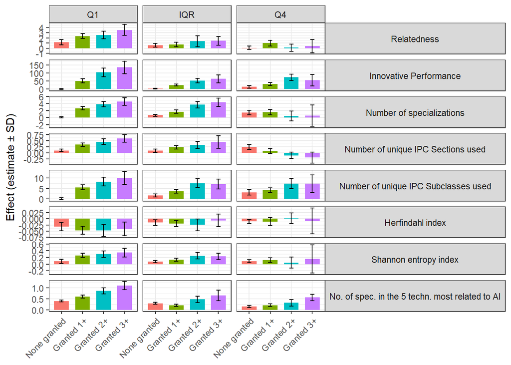

```r
ggplot(df_long, aes(x = Group, y = ATT, fill = Group)) +
  geom_col(width = 0.7) +
  geom_errorbar(aes(ymin = ATT - Std_Error, ymax = ATT + Std_Error), width = 0.2) +
  facet_grid(rows = vars(Variable), cols = vars(Q), scales = "free_y") +
  labs(y = "Effect (estimate ± SD)", x = NULL) +
  theme_bw() +
  theme(axis.text.x = element_text(angle = 45, hjust = 1),
        legend.position = "none",
        strip.text.y = element_text(angle = 0))
```

# 3. Descriptive statistics and correlations

This section provides descriptive statistics and correlation analyses for the datasets used in the study. We first examine the characteristics of all MNEs in the dataset, grouped by their quartile of technological proximity to AI. Then, we focus on the matched sample of companies, comparing the descriptive statistics of treated and control groups. Finally, we visualize the correlations between key variables.

## 3.1. Statistics All data

The following analysis presents a statistical summary of the entire dataset of MNEs, with companies categorized into quartiles based on their technological distance to AI.

```r
rm(list=ls())

FinalDataset <- read.csv("Input_code/Data_all_MNEs_2019.csv", sep = ";", header = TRUE, dec = ",")
FinalDataset$Nace_4d <- as.character(FinalDataset$Nace_4d)

CategoriesNace <- read.csv("Output_code/Data/Distance_measure.csv", header = TRUE)
CategoriesNace$Nace_4d <- as.character(CategoriesNace$Nace_4d)

FinalDataset <- left_join(FinalDataset, CategoriesNace, by = "Nace_4d")
FinalDataset$Quartile[is.na(FinalDataset$Quartile)] <- "Bottom"

# Select the variables for the summary table
FinalDataset_summary <- FinalDataset[,c("Relatedness_Cos2", "NoSubs_calculated", "NoSubsWithPatents", "Size_class",
                                             "NoPatentsYearGUOtotal", "No_AI_PatentsYearGUOtotal", "No_employees_Year",
                                             "Date_Incorporation",  "Specializations_Number",
                                             "Herfindahl", "Shannon", "Quartile",
                                             "UniqueCodes", "UniqueSubclass")]
```

The table below shows descriptive statistics for all MNEs, broken down by quartile of proximity to AI.

```r
st(FinalDataset_summary, group = "Quartile",  group.test = TRUE,
   summ = c('mean(x)','median(x)','sd(x)','min(x)','pctile(x)[25]','pctile(x)[75]','max(x)'), out = 'return')
```

| Variable | Mean | Median | Sd | Min | Pctile[25] | Pctile[75] | Max | Mean | Median | Sd | Min | Pctile[25] | Pctile[75] | Max | Mean | Median | Sd | Min | Pctile[25] | Pctile[75] | Max | Test |
| --- | --- | --- | --- | --- | --- | --- | --- | --- | --- | --- | --- | --- | --- | --- | --- | --- | --- | --- | --- | --- | --- | --- |
| Quartile | Bottom |  |  |  |  |  |  | IQR |  |  |  |  |  |  | Top |  |  |  |  |  |  |  |
| Relatedness_Cos2 | 8.3 | 3 | 11 | 0 | 0 | 15 | 56 | 8.1 | 2 | 11 | 0 | 0 | 14 | 70 | 8.2 | 4 | 10 | 0 | 0 | 14 | 56 | F=1.224 |
| NoSubs_calculated | 19 | 4 | 75 | 0 | 1 | 12 | 3481 | 16 | 4 | 67 | 0 | 2 | 10 | 3295 | 20 | 5 | 73 | 0 | 2 | 14 | 2657 | F=5.679*** |
| NoSubsWithPatents | 1.4 | 0 | 3.9 | 0 | 0 | 1 | 112 | 1.3 | 1 | 3 | 0 | 0 | 1 | 75 | 1.2 | 0 | 3 | 0 | 0 | 1 | 96 | F=12.23*** |
| Size_class | 9330 |  |  |  |  |  |  | 11961 |  |  |  |  |  |  | 5681 |  |  |  |  |  |  | X2=861.978*** |
| ... Large company | 2678 | 29% |  |  |  |  |  | 3007 | 25% |  |  |  |  |  | 892 | 16% |  |  |  |  |  |  |
| ... Medium sized company | 1391 | 15% |  |  |  |  |  | 2246 | 19% |  |  |  |  |  | 839 | 15% |  |  |  |  |  |  |
| ... Small company | 623 | 7% |  |  |  |  |  | 1799 | 15% |  |  |  |  |  | 693 | 12% |  |  |  |  |  |  |
| ... Very large company | 4638 | 50% |  |  |  |  |  | 4909 | 41% |  |  |  |  |  | 3257 | 57% |  |  |  |  |  |  |
| NoPatentsYearGUOtotal | 94 | 6 | 547 | 0 | 2 | 28 | 20512 | 58 | 5 | 378 | 0 | 2 | 22 | 17615 | 84 | 5 | 523 | 0 | 1 | 25 | 13581 | F=15.9*** |

[output cut: 8 more lines]

This table is saved as **“Descriptive_statistics_all_MNEs_by_Quartile.csv”**

## 3.2. Statistics matched data

This part of the analysis focuses on the subset of companies that were matched for the Difference-in-Differences (DiD) estimation. We compare the descriptive statistics of the treated group (companies that introduced AI) and the control group (companies that did not).

```r
DataLong_Subs_2006 <- read.csv("Input_code/Matched_companies.csv", sep = ";", header = TRUE, dec = ",")

# Calculate the mean of the last 5 years for a variable
DataLong_Subs_2006 %<>% group_by(Company, subclass) %>%
  mutate(across(NoPatentsYearGUOtotal,
                .fns = list(avg = ~ zoo::rollmean(., k = 5, fill = NA, align = 'center'))))

# Create lagged variables
DataLong_Subs_2006 %<>% group_by(Company, subclass) %>%
  mutate(NoPatentsYearGUOtotal_avg_fixed = lag(NoPatentsYearGUOtotal_avg)) %>%
  mutate(Relatedness_lagged = lag(Relatedness_Cos2))

DataLong_Subs_2006 <- subset(DataLong_Subs_2006, select = -c(NoPatentsYearGUOtotal_avg))

# Merge with the full dataset to get Quartile information
For_Match <- FinalDataset[, c("Company", "CurrentYear", "Quartile", "Specializations_Number", "Shannon", "Herfindahl", "NoSubs_calculated", "NoSubsWithPatents", "No_employees_Year", "UniqueCodes", "UniqueSubclass")]
DataLong_Subs_2006 <- left_join(DataLong_Subs_2006, For_Match, by = c("Company", "CurrentYear"), na_matches = "never")
rm(For_Match)

DataLong_Subs_2006 %<>% group_by(Company, subclass) %>%
  mutate(N_specializations_lagged = lag(Specializations_Number.x))

# Select variables for the summary table
DataLong_Subs_2006_summary <- DataLong_Subs_2006[,c("Relatedness_Cos2", "Size_class", "NoPatentsYearGUOtotal", "No_AI_PatentsYearGUOtotal",
                                                    "Company", "treat", "Date_Incorporation", "Group", "CurrentYear",
                                                    "NoPatentsYearGUOtotal_avg_fixed", "Nace_4d", "YearFirstAdoption",
                                                    "Specializations_Number.x", "Shannon.x", "Herfindahl.x", "NoSubs_calculated", "NoSubsWithPatents",
                                                    "Quartile", "No_employees_Year",
                                                    "Relatedness_lagged", "N_specializations_lagged",
                                                    "UniqueCodes.x", "UniqueSubclass.x" )]

DataLong_Subs_2006_summary <- DataLong_Subs_2006_summary[DataLong_Subs_2006_summary$Group == DataLong_Subs_2006_summary$CurrentYear, ]

DataLong_Subs_2006_summary <- subset(DataLong_Subs_2006_summary, select = -c(Company, Group, YearFirstAdoption, Nace_4d))
```

The table below shows descriptive statistics for the matched treated and control companies.

```r
st(DataLong_Subs_2006_summary, group = "treat", group.test = TRUE,
   summ = c('mean(x)','median(x)','sd(x)','min(x)','pctile(x)[25]','pctile(x)[75]','max(x)'), out = 'return')
```

| Variable | Mean | Median | Sd | Min | Pctile[25] | Pctile[75] | Max | Mean | Median | Sd | Min | Pctile[25] | Pctile[75] | Max | Test |
| --- | --- | --- | --- | --- | --- | --- | --- | --- | --- | --- | --- | --- | --- | --- | --- |
| treat | 0 |  |  |  |  |  |  | 1 |  |  |  |  |  |  |  |
| Relatedness_Cos2 | 13 | 11 | 11 | 0 | 2 | 20 | 53 | 14 | 13 | 11 | 0 | 5 | 21 | 53 | F=8.497*** |
| Size_class | 1257 |  |  |  |  |  |  | 1257 |  |  |  |  |  |  | X2=0 |
| ... Large company | 161 | 13% |  |  |  |  |  | 161 | 13% |  |  |  |  |  |  |
| ... Medium sized company | 122 | 10% |  |  |  |  |  | 122 | 10% |  |  |  |  |  |  |
| ... Small company | 98 | 8% |  |  |  |  |  | 98 | 8% |  |  |  |  |  |  |
| ... Very large company | 876 | 70% |  |  |  |  |  | 876 | 70% |  |  |  |  |  |  |
| NoPatentsYearGUOtotal | 88 | 20 | 232 | 0 | 5 | 79 | 3387 | 103 | 28 | 240 | 1 | 6 | 94 | 3137 | F=2.596 |
| No_AI_PatentsYearGUOtotal | 0 | 0 | 0 | 0 | 0 | 0 | 0 | 1.3 | 1 | 0.89 | 1 | 1 | 1 | 9 | F=2832.872*** |
| Date_Incorporation | 1992 | 1999 | 27 | 1654 | 1986 | 2008 | 2019 | 1990 | 1999 | 29 | 1807 | 1987 | 2008 | 2020 | F=1.065 |

[output cut: 16 more lines]

This table is saved as **“Descriptive_statistics_matched_companies_Treated.csv”**.

## 3.3. Analyse correlations

Finally, we visualize the correlations between key variables for both the matched sample and the entire dataset. This helps to identify potential relationships and multicollinearity among the variables.

**Matched Sample**

Here is the correlation plot for the matched companies.

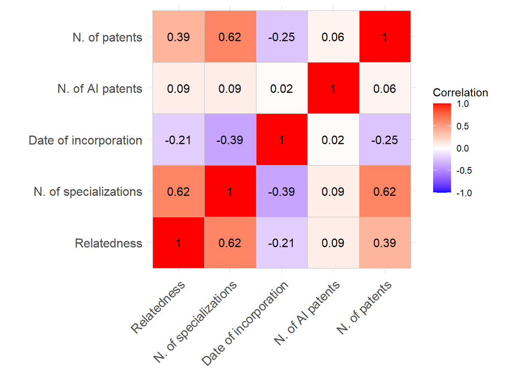

```r
data_normalized <- DataLong_Subs_2006_summary[, c("Relatedness_Cos2", "Specializations_Number.x",
                                                 "Date_Incorporation", "No_AI_PatentsYearGUOtotal", "NoPatentsYearGUOtotal")]

names(data_normalized) <- c("Relatedness", "N. of specializations", "Date of incorporation", "N. of AI patents", "N. of patents")
data_normalized <- scale(data_normalized)
corr_matrix <- cor(na.omit(data_normalized))

ggcorrplot(corr_matrix, legend.title = "Correlation", hc.order = F, lab = TRUE)
```

**All MNEs**

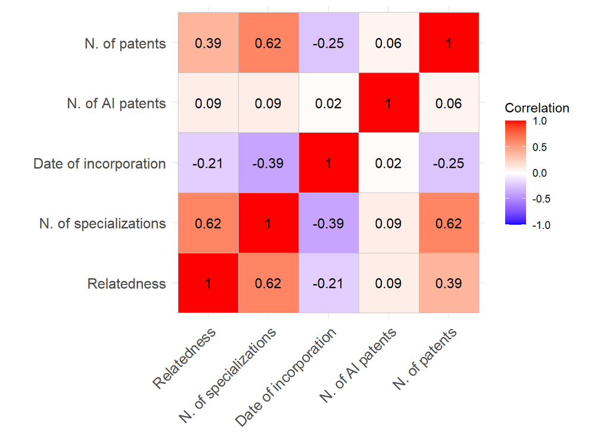

```r
ggcorrplot(corr_matrix, legend.title = "Correlation", hc.order=F,lab = TRUE)
```

And now for the whole dataset:

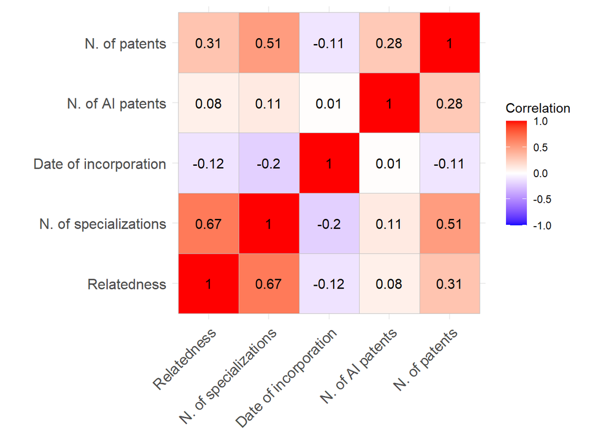

```r
data_normalized <- FinalDataset[, c("Relatedness_Cos2", "Specializations_Number",
                                   "Date_Incorporation", "No_AI_PatentsYearGUOtotal", "NoPatentsYearGUOtotal")]

names(data_normalized) <- c("Relatedness", "N. of specializations", "Date of incorporation", "N. of AI patents", "N. of patents")
data_normalized <- scale(data_normalized)
corr_matrix <- cor(na.omit(data_normalized))

ggcorrplot(corr_matrix, legend.title = "Correlation", hc.order = F, lab = TRUE)
```